# Project Satisfaction

Personal contribution:

- Pankova Yulia: clusterization, design of policy 1 and models 1, monetary gain/loss accounting, creating the executive summary
- Zakharchenko Varvara: design of policy 2 and models 2, interpreting log-odds coefficients, creating the executive summary
- Polina Rogacheva (50% of the work) and Liana Pankatova (50% of the work): made the EDA of all significant variables, reviewed and calculated business metrics, made a literature review in the 3rd part of the project, constructed the Bayesian Belief Network and What-If Analysis

#### Goal of this project:

We are going to examine the data, find some trends and patterns in the distribution of Satisfaction status on the basis of the other predictors, present some business-metrics, and think about possible reasons for disSatisfaction of the users.

# 1. Exploratory analysis & Business Metrics

### Basic statistics

First step: loading the data and necessary libraries.

Next step: eyeballing the data and get some descriptive explanation of the data.

```
##     Gender               Age        Loyalty_card        Home.City
##  Length:62988       Min.   : 7.00   Length:62988       Length:62988
##  Class :character   1st Qu.:23.00   Class :character   Class :character
##  Mode  :character   Median :33.00   Mode  :character   Mode  :character
##                     Mean   :35.44
##                     3rd Qu.:48.00
##                     Max.   :85.00
##
##     Class           Flight.Distance  Flight.Count    First.Flight.Date
##  Length:62988       Min.   :  50    Min.   :  2.00   Length:62988
##  Class :character   1st Qu.:1440    1st Qu.:  3.00   Class :character
##  Mode  :character   Median :1872    Median :  7.00   Mode  :character
##                     Mean   :1874    Mean   : 11.84
##                     3rd Qu.:2304    3rd Qu.: 15.00
##                     Max.   :6951    Max.   :213.00
##
##  Last.Flight.Date     Avg.Check      Satisfaction        Seat.comfort
##  Length:62988       Min.   : 18530   Length:62988       Min.   :0.000
##  Class :character   1st Qu.: 29984   Class :character   1st Qu.:2.000
##  Mode  :character   Median : 41475   Mode  :character   Median :3.000
##                     Mean   : 47846                      Mean   :2.795
##                     3rd Qu.: 51724                      3rd Qu.:4.000
##                     Max.   :119983                      Max.   :5.000
##
##  Departure.Arrival.time.convenient Food.and.drink  Gate.location
##  Min.   :0.00                      Min.   :0.000   Min.   :0.000
##  1st Qu.:2.00                      1st Qu.:2.000   1st Qu.:2.000
##  Median :3.00                      Median :3.000   Median :3.000
##  Mean   :3.02                      Mean   :2.735   Mean   :2.966
##  3rd Qu.:4.00                      3rd Qu.:4.000   3rd Qu.:4.000
##  Max.   :5.00                      Max.   :5.000   Max.   :5.000
##
##  Inflight.wifi.service Inflight.entertainment Online.support
##  Min.   :0.00          Min.   :0.000          Min.   :1.000
##  1st Qu.:2.00          1st Qu.:2.000          1st Qu.:2.000
##  Median :3.00          Median :3.000          Median :4.000
##  Mean   :3.15          Mean   :3.021          Mean   :3.285
##  3rd Qu.:4.00          3rd Qu.:4.000          3rd Qu.:4.000
##  Max.   :5.00          Max.   :5.000          Max.   :5.000
##
```

[output cut: 9 more lines]

```
##  Min.   :1.000   Min.   :1.000   Min.   :1.000   Min.   :   0.00
##  1st Qu.:3.000   1st Qu.:3.000   1st Qu.:2.000   1st Qu.:   0.00
##  Median :3.000   Median :4.000   Median :3.000   Median :   0.00
##  Mean   :3.362   Mean   :3.763   Mean   :3.235   Mean   :  14.65
##  3rd Qu.:4.000   3rd Qu.:5.000   3rd Qu.:4.000   3rd Qu.:  12.00
##  Max.   :5.000   Max.   :5.000   Max.   :5.000   Max.   :1592.00
##
##  Arrival.Delay.in.Minutes
##  Min.   :   0.00
##  1st Qu.:   0.00
##  Median :   0.00
##  Mean   :  15.07
##  3rd Qu.:  13.00
##  Max.   :1584.00
##  NA's   :207
```

| Rows | Columns | NAs | Non-NAs |
| --- | --- | --- | --- |
| 62988 | 27 | 207 | 1700469 |

So, we have 27 variables in the initial dataset. Additionally, we converted variables of dates do date format.

Next, the amount of NA’s is just 207 in our dataset, in the variable that describes a “delay in minutes”. For 62988 records it is a pretty insignificant number, so we remove them.

Now the dimension of our data is:

```r
data = data %>% mutate(first_flight_date = as.Date(First.Flight.Date, "%m/%d/%Y"), last_flight = as.Date(Last.Flight.Date, "%m/%d/%Y")) %>% na.omit() %>% filter(!((first_flight_date > last_flight)|(year(first_flight_date) == 1905))) %>% dplyr::select(-c(First.Flight.Date, Last.Flight.Date))

d1 <- as.data.frame(cbind(dim(data)[1], dim(data)[2]))
colnames(d1) <- c("Rows", "Columns")

d1 %>% kable() %>%
  kable_styling(bootstrap_options = "striped", full_width = F, position = "left")
```

| Rows | Columns |
| --- | --- |
| 62352 | 27 |

So, we have 62352 unique customers and 27 var-s to track them.

The most disturbing question: what is the distribution of satisfied/unsatisfied customers across the data?

```r
d1 <- as.data.frame(cbind(table(data$Satisfaction)[1], table(data$Loyalty_card)[2]))
rownames(d1) <- ""
colnames(d1) <- c("Dissatisfied", "Satisfied")

d1 %>% kable() %>%
  kable_styling(bootstrap_options = "striped", full_width = F, position = "left", )
```

[output not shown]

### Visualization

**Plot 1**: Here we observe the loyalty cards and their spreading across Satisfaction group.

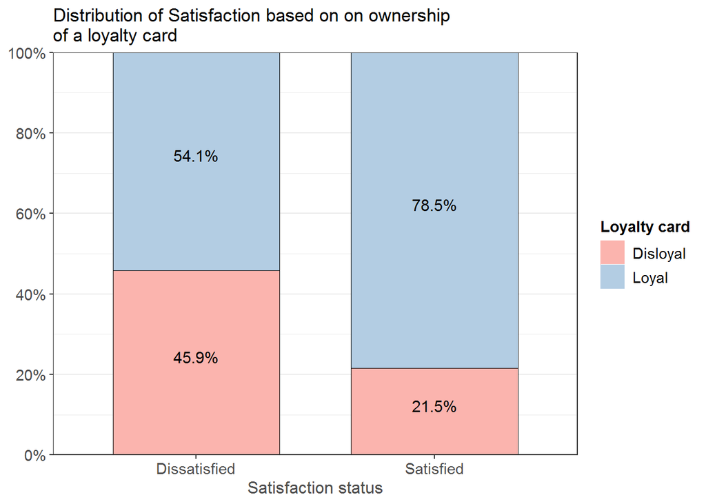

```r
library(sjPlot)
set_theme(base = theme_bw())
plot_xtab(data$Satisfaction, data$Loyalty_card,
          margin = "row",
          bar.pos = "stack",show.legend = T, show.n=F,
          title = "Distribution of Satisfaction based on on ownership of a loyalty card",
          axis.titles = "Satisfaction status",
          legend.title = "Loyalty card",
          geom.colors = "Pastel1")
```

So, seems like those who own a loyalty card are more likely to be satisfied with our company.

As there are several scores on quality of services based on the clients satisfaction and we can see that satisfied customers tend to be loyal in a higher degree we will make satisfaction the target of our research.

Let’s check the relationsip between these two variables statistically:

```r
chisq = chisq.test(data$Loyalty_card, data$Satisfaction)
chisq
```

```
##
##  Pearson's Chi-squared test with Yates' continuity correction
##
## data:  data$Loyalty_card and data$Satisfaction
## X-squared = 3740.2, df = 1, p-value < 0.00000000000000022
```

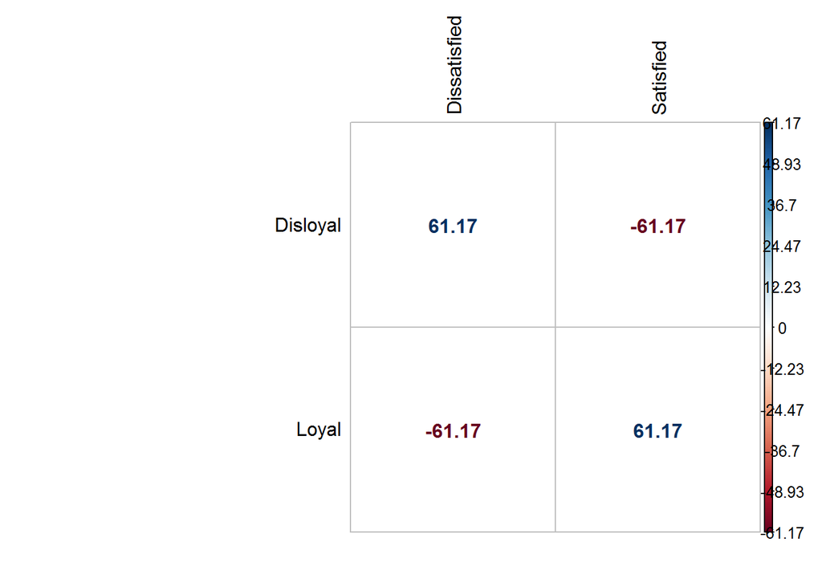

```r
corrplot(chisq$stdres, method = "number", is.cor = FALSE, tl.col = "black")
```

We observe p-value to be <0.05 and thus be statistically significant: it reports about the ture relationship between these two variables. The corrplot of standartized residuals reports that many more disloyal customers are dissatisfied than it was expected if these variables will be independent - and vice versa.

Hence, we find it logical to construct our predictions for satisfaction of customers. We are going to develop strategies to upper satisfaction status and encourage more customers to be loyal.

**Plot 2**: what is the percentage of dissatisfied customers?:

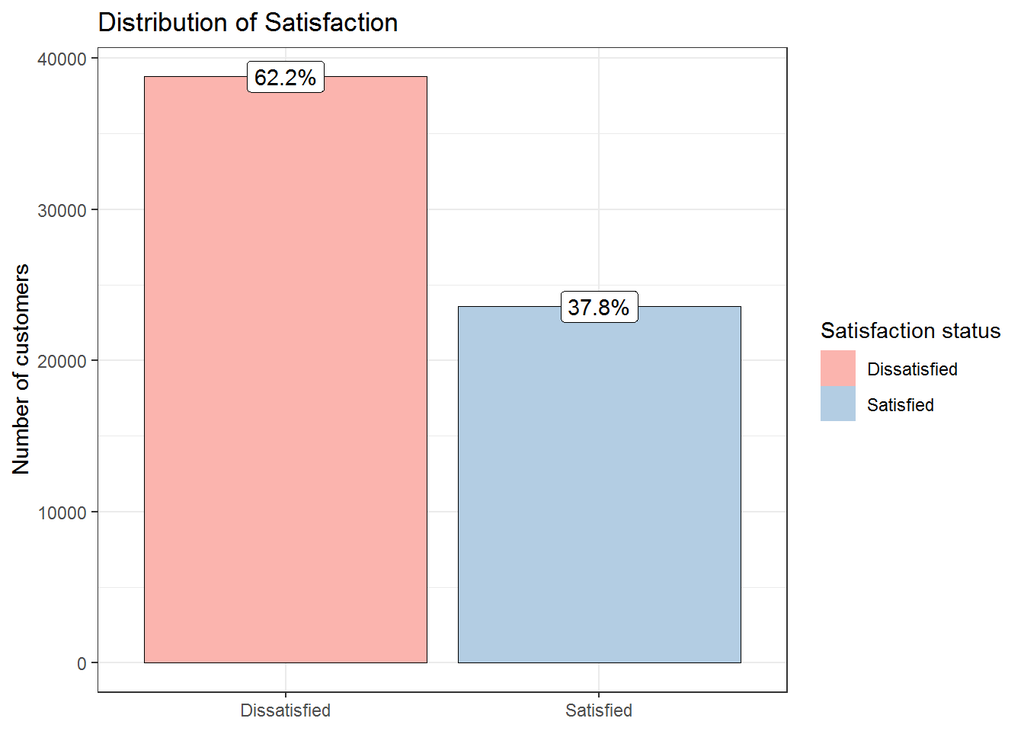

```r
library(stringr)
ggplot(data, aes(x = Satisfaction)) + geom_bar(aes(fill = Satisfaction)) + scale_fill_manual(name = "Satisfaction status", values = c( "Dissatisfied" = "#FBB4AE", "Satisfied" = "#B3CDE3"), labels = c("Dissatisfied","Satisfied")) + geom_label(aes(label= str_c(round(stat(prop)*100, digits = 2), "%"), group=1),stat='count') + ggtitle("Distribution of Satisfaction") + theme_bw() + labs(x = NULL, y = "Number of customers")
```

Thus, approximately 62% ofclients are dissatisfied and about 38% of them - vice versa. Worth to say, such distribution is useful for Satisfaction predictions.

**Plot 3**: How does the distribution of Satisfaction among gender look like?

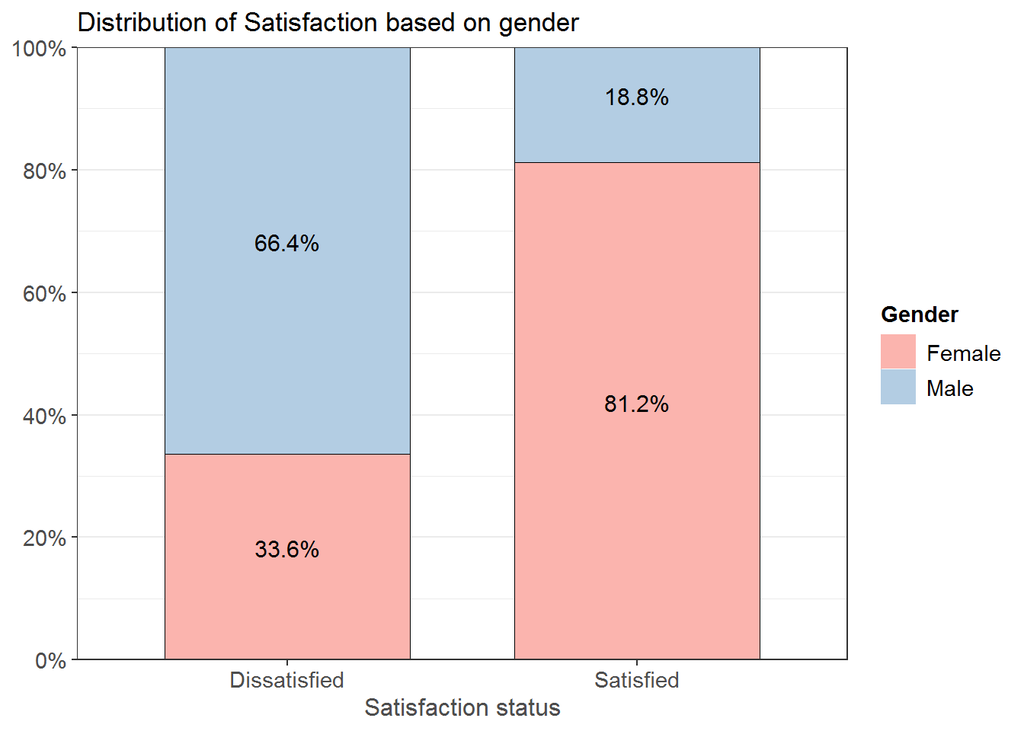

```r
plot_xtab(data$Satisfaction, data$Gender,
          margin = "row",
          bar.pos = "stack",show.legend = T, show.n=F,
          title = "Distribution of Satisfaction based on gender",
          axis.titles = "Satisfaction status",
          legend.title = "Gender",
          geom.colors = "Pastel1")
```

Males are dissatisfyed considerably more.

**Plot 4**: How does the distribution of Satisfaction among age look like?

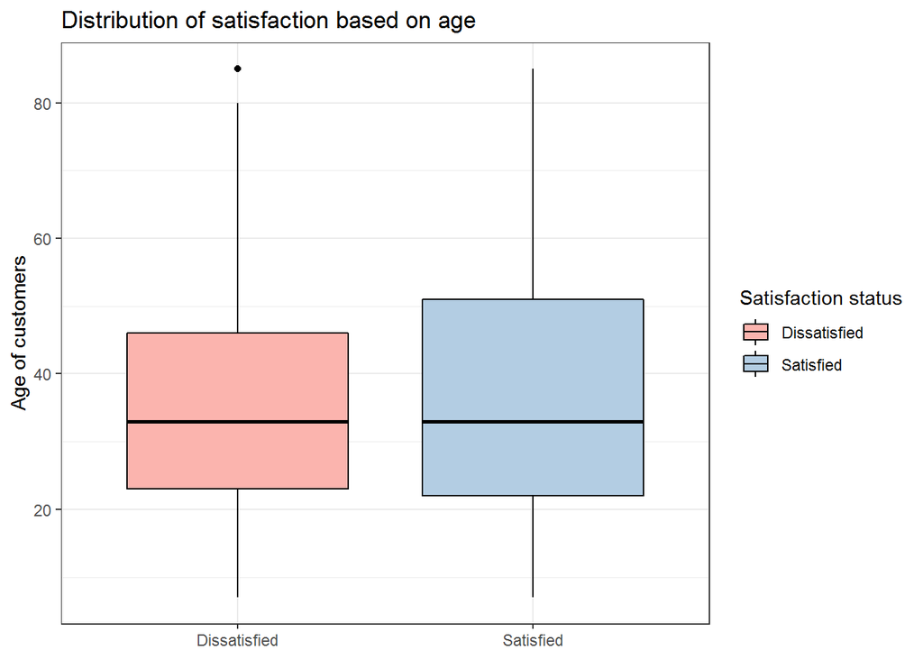

```r
ggplot(data, aes(x = Satisfaction, y = Age, fill = Satisfaction)) + geom_boxplot() + labs(x = NULL, y = "Age of customers") + theme(legend.position = "none") + ggtitle("Distribution of satisfaction based on age") +  scale_fill_manual(name = "Satisfaction status", values = c( "Dissatisfied" = "#FBB4AE", "Satisfied" = "#B3CDE3"), labels = c("Dissatisfied","Satisfied")) + theme_bw()
```

We cannot observe any difference here.

**Plot 5**: How does the distribution of Satisfaction among average check look like?

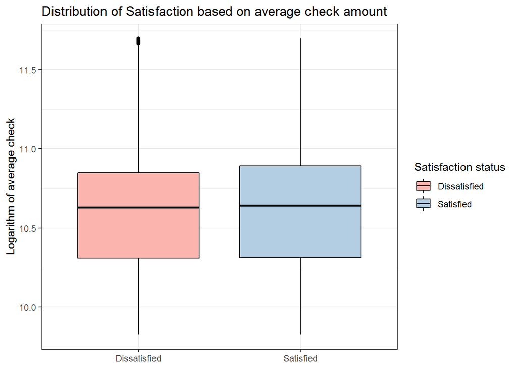

```r
ggplot(data, aes(x = Satisfaction, y = log(Avg.Check), fill = Satisfaction)) + geom_boxplot() + labs(x = NULL) +ggtitle("Distribution of Satisfaction based on average check amount") + scale_fill_manual(name = "Satisfaction status", values = c( "Dissatisfied" = "#FBB4AE", "Satisfied" = "#B3CDE3")) + theme_bw() + labs(y = "Logarithm of average check")
```

We cannot observe any difference here.

**Plot 6**: How does the distribution of Satisfaction among amount of flights per customer look like?

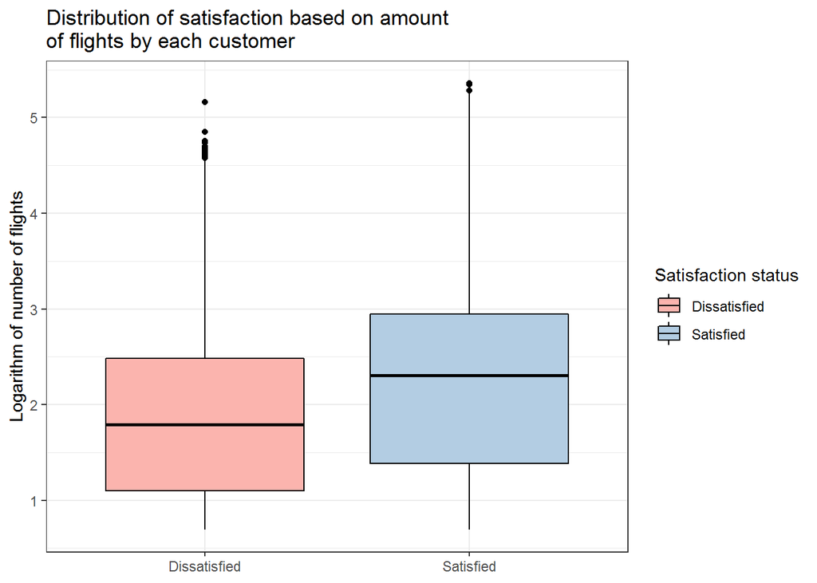

```r
ggplot(data, aes(x = Satisfaction, y = log(Flight.Count), fill = Satisfaction)) + geom_boxplot() + labs(x = NULL) + ggtitle("Distribution of satisfaction based on amount \nof flights by each customer") + scale_fill_manual(name = "Satisfaction status", values = c( "Dissatisfied" = "#FBB4AE", "Satisfied" = "#B3CDE3"), labels = c("Dissatisfied","Satisfied")) + theme_bw() + labs(y = "Logarithm of number of flights")
```

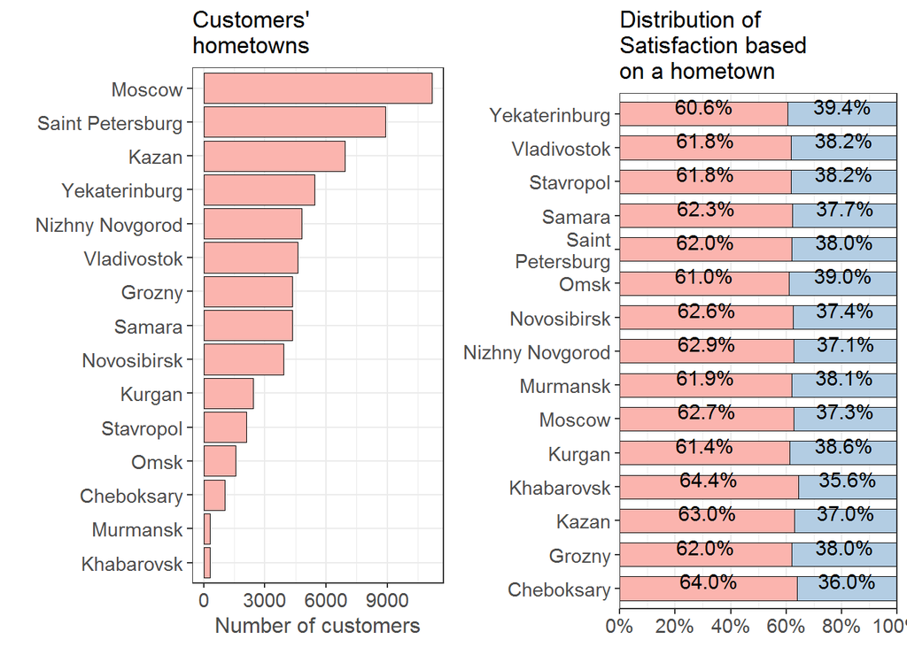

```r
a <- ggplot(data = data, aes(reorder(Home.City, table(Home.City)[Home.City]))) + geom_bar(fill = "#FBB4AE") + coord_flip() + xlab("") + ylab("Number of customers") + ggtitle("Customers'\nhometowns")

b <- plot_xtab(data$Home.City, data$Satisfaction,
          margin = "row",
          bar.pos = "stack",show.legend = F, show.n=F,
          title = "Distribution of \nSatisfaction based \non a hometown",
          axis.titles = "",
          legend.title = "Satisfaction",
          geom.colors = "Pastel1",
          coord.flip = T)


library(cowplot)
cowplot::plot_grid(a,b)
```

**Plot 8**: How does the distribution of Satisfaction among flight distance look like?

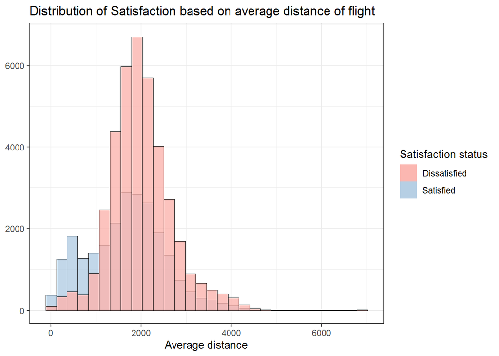

```r
data %>% dplyr::select(Flight.Distance, Satisfaction) %>% ggplot(aes(x = Flight.Distance)) + geom_histogram(data = data %>% filter(Satisfaction == "Satisfied"), aes(fill = "Satisfied"), alpha = 0.8, bins = 30) + geom_histogram(data = data %>% filter(Satisfaction == "Dissatisfied"), aes(fill = "Dissatisfied"), alpha = 0.8, bins = 30) + labs(x = "Average distance", y = NULL, color = "Satisfaction status") + scale_fill_manual(name = "Satisfaction status", values = c("Dissatisfied" = "#FBB4AE", "Satisfied" = "#B3CDE3"), labels = c("Dissatisfied","Satisfied")) + theme_bw() + ggtitle("Distribution of Satisfaction based on average distance of flight")
```

As we can see from the plot, averagely both classes have peaks in 1500-2500 units of fly distance. Nevertheless, only several number of satisfied clients enjoyed the flight with larger distance. From another point of view, dissatisfied clients are shown in some outliers reaching its highest points at roundly 4000.

**Plot 8**: How does the distribution of Satisfaction among last flight date look like according to the preiods of half of the year?

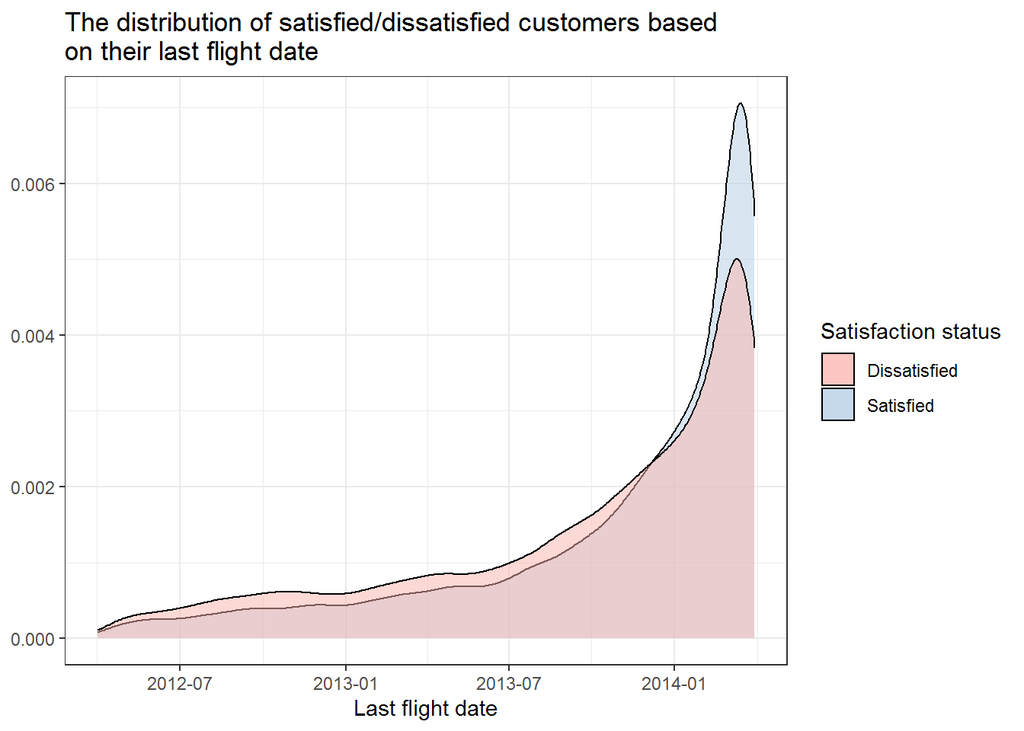

```r
data %>% dplyr::select(last_flight, Satisfaction) %>% ggplot(aes(x = last_flight)) + geom_density(data = data %>% filter(Satisfaction == "Satisfied"), aes(fill = "Satisfied"), alpha = 0.5) + geom_density(data = data %>% filter(Satisfaction == "Dissatisfied"), aes(fill = "Dissatisfied"), alpha = 0.5) + labs(x = "Last flight date", y = NULL, color = "Satisfaction status") + scale_fill_manual(name = "Satisfaction status", values = c("Dissatisfied" = "#FBB4AE", "Satisfied" = "#B3CDE3"), labels = c("Dissatisfied","Satisfied")) + theme_bw() + ggtitle("The distribution of satisfied/dissatisfied customers based \non their last flight date")
```

As we can see it on the graph the difference between two groups of satisfaction until January 2014. However, after this month there began to be more satisfied than dissatisfied customers. Probably we should explore what changes appear in this period and how we can improve level of customers Satisfaction more.

We also have customers’ opinions on several factors of firm service. We decided to divide them into 3 parts - online services, on-board services, and services in the airports. The first part will include variables on online support, online booking, and online boarding, the second one - Cleanliness, onboard service, inflight entertainment, inflight wifi, food and drinks, seat comfort, and legroom service. And the last one will include variables on the convenience of departure and arrival time, gate location, baggage handling, check-in service. We will calculate the average score given by customers for these types of services and look at the connection between them and Satisfaction. Which services are more important for customers’ Satisfaction?

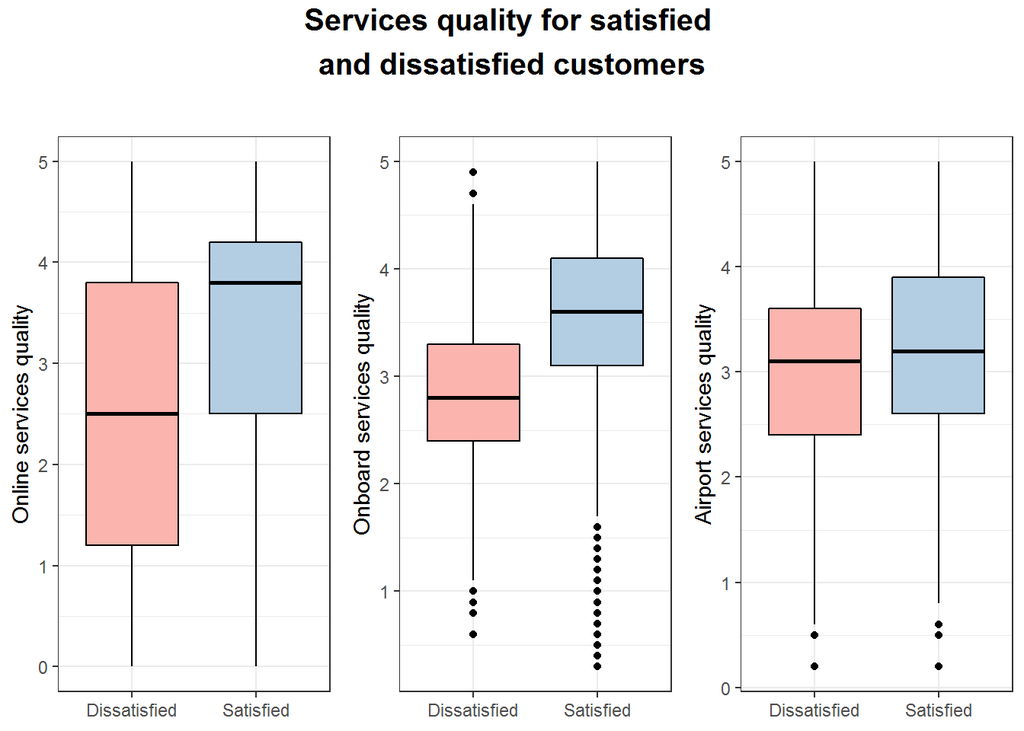

```r
data = data %>% mutate(online_services = round((Online.support+Online.boarding+Ease.of.Online.booking)/3, 1), On.board.services = round((Cleanliness+On.board.service+Inflight.entertainment+Inflight.wifi.service+Food.and.drink+Seat.comfort+Leg.room.service)/7,1), airport_services = round((Departure.Arrival.time.convenient+Gate.location+Baggage.handling+Checkin.service)/4, 1))


online = ggplot(data) + geom_boxplot(aes(Satisfaction, online_services, fill = Satisfaction)) + theme_bw() + scale_fill_manual(name = "Satisfaction status", values = c("Dissatisfied" = "#FBB4AE", "Satisfied" = "#B3CDE3"), labels = c("Dissatisfied","Satisfied")) + labs(x = NULL, y = "Online services quality") + theme(legend.position = "none")
onboard = ggplot(data) + geom_boxplot(aes(Satisfaction, On.board.services, fill = Satisfaction)) + theme_bw() + scale_fill_manual(name = "Satisfaction status", values = c("Dissatisfied" = "#FBB4AE", "Satisfied" = "#B3CDE3"), labels = c("Dissatisfied","Satisfied")) + labs(x = NULL, y = "Onboard services quality") + theme(legend.position = "none")
airport = ggplot(data) + geom_boxplot(aes(Satisfaction, airport_services, fill = Satisfaction)) + theme_bw() + scale_fill_manual(name = "Satisfaction status", values = c("Dissatisfied" = "#FBB4AE", "Satisfied" = "#B3CDE3"), labels = c("Dissatisfied","Satisfied")) + labs(x = NULL, y = "Airport services quality")+ theme(legend.position = "none")

plot1 = ggarrange(online, onboard, airport, ncol = 3, nrow = 1)
annotate_figure(plot1, top = text_grob("Services quality for satisfied \nand dissatisfied customers\n", face = "bold", size = 15),)
```

The plot illustrates that there are big differences between scores for satisfied and dissatisfied customers in online and on-board services. The difference in scores for airport services is not so substantial. It can be connected with the fact that airport services are associated with airlines quality in a smaller way than online and on-board services are.

### Business metrics

Let’s count the revenue per user.

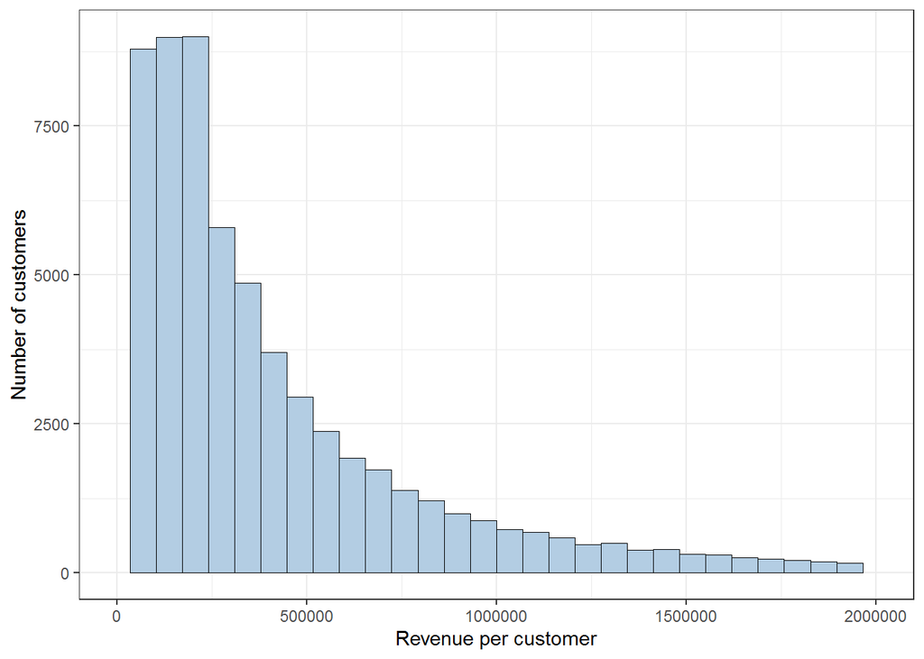

```r
data$revenue = data$Avg.Check * data$Flight.Count
ggplot(data) + geom_histogram(aes(revenue), fill = "#B3CDE3") + theme_bw() + labs(x = "Revenue per customer", y = "Number of customers") + scale_x_continuous(limits = c(0,2000000))
```

Let’s count sticky factor and all metrics that go along with it. DAU, MAU, WAU will be counted for the year of 2013, because we rely on the latest available data of variable *last_flight* and our date of analysis is 2013-10-01.

```r
data_dau_13 = data %>% filter(year(last_flight) == "2013") %>% group_by(last_flight) %>% dplyr::summarise(n = n())
dau = as.data.frame(mean(data_dau_13$n))
colnames(dau) <- "DAU"
data_wau_13 = data %>% filter(year(last_flight) == "2013") %>% group_by(week(last_flight)) %>% dplyr::summarise(n = n())
wau = as.data.frame(mean(data_wau_13$n))
colnames(wau) <- "WAU"
data_mau_13 = data %>% filter(year(last_flight) == "2013") %>% group_by(month(last_flight)) %>% dplyr::summarise(n = n())
mau = as.data.frame(mean(data_mau_13$n))
colnames(mau) <- "MAU"
a <- as.data.frame(cbind(stick_week = dau/wau * 100, stick_month = dau/mau * 100))
colnames(a) <- c("Weekly Sticky", "Monthly Sticky")
data_satisf = data %>% group_by(Satisfaction) %>% dplyr::summarise(n = n())
csat = data_satisf[2,2] / sum(data_satisf[,2])
csat_score = csat * 100
colnames(csat_score) <- "CSAT"
cbind(dau, wau, mau, a, csat_score) %>% kable() %>% kable_styling(bootstrap_options = "striped", full_width = F, position = "left")
```

| DAU | WAU | MAU | Weekly Sticky | Monthly Sticky | CSAT |
| --- | --- | --- | --- | --- | --- |
| 73.18356 | 504 | 2226 | 14.52055 | 3.287671 | 37.7951 |

We can see that:

- DAU: on average 73 customers fly per day.
- WAU: average 504 customers fly per week
- MAU: on average 2226 customers fly per month.
- The monthly Sticky is roughly 3.3% which means that on average 3% had a flight each day every month.
- The Weekly Sticky is approximately 14.5% which which means that one average 14,5% had a flight each day every week.
- the Customer Satisfaction Score is roughly 37,8%, which is not great.

Let’s count RFM (recency, frequency, monetary) scores and metric. We will divide customers into 5 categories by recency, frequency and monetary value of their flights. Than we will calculate weighted value for rfm.

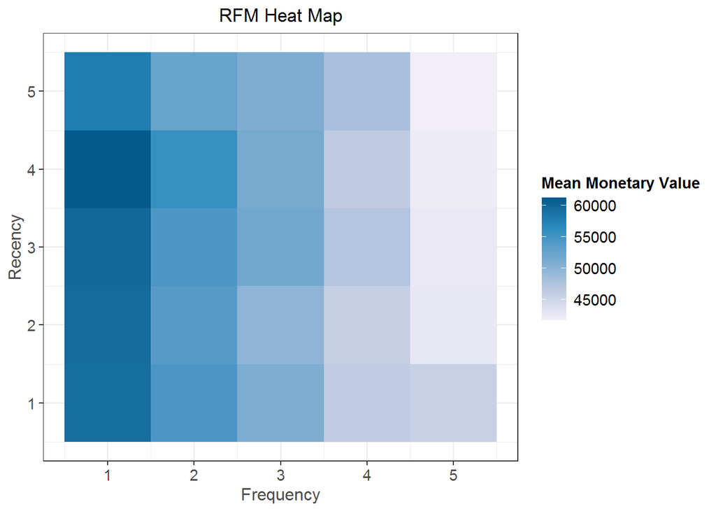

```r
analysis_date = lubridate::as_date("2013-10-01")
data$id = rownames(data)
rfm = data %>% dplyr::select(id, Flight.Count, Avg.Check, last_flight, Satisfaction) %>% mutate(recency = as.numeric(analysis_date - last_flight)) %>% filter(recency>=0)


rfm_results = rfm_table_customer(data = rfm, customer_id = id, n_transactions = Flight.Count, recency_days = recency, total_revenue = Avg.Check,  recency_bins = 5, frequency_bins = 5, monetary_bins = 5,)
rfm_table = rfm_results$rfm
rfm_heatmap(rfm_results)
```

The plot illustrates that even clients with low scores for frequency tend to spend more money on average. The most profitable for the company type of client is the group with 4 for recency and 1 for frequency scores.

Let’s take a look at the Frequency VS Monetary

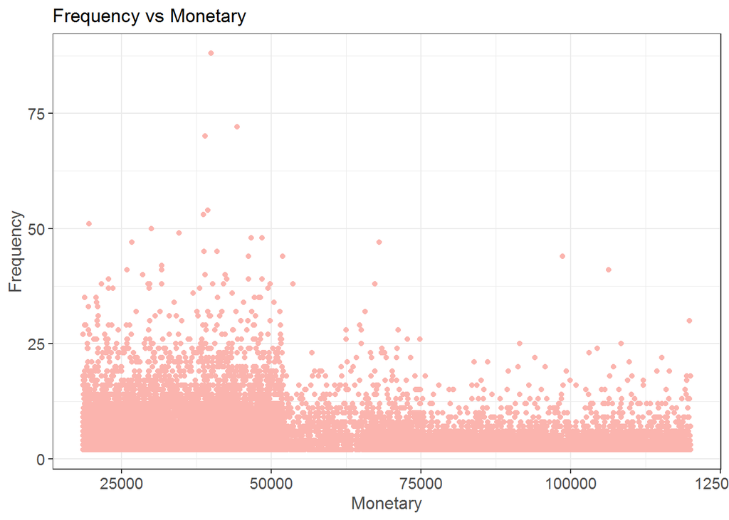

```r
rfm_fm_plot(rfm_results, point_color = "#FBB4AE")
```

Here we can see that clients tend to spend more money on average when they flight not so frequently.

### Hypothesis

Finally, let’s write out the hypothesis on the basis of our exploratory analysis:

The first set of hypothesis includes stable variables that we cannot change, e.g. gender:

1. As males are positively associated with higher dissatisfaction level, airline services should pay more attention to male audience, e. g. some gender-specific campaigns probably
2. Women are positively associated with higher level of satisfaction with airline services

The next set of hypothesis is related to changeable variables, e.g. quality of airline services of various type:

1. Satisfied customers on average make more flights
2. Online airline services are positively associated with higher level of satisfaction of airline services
3. Onboard services quality are positively associated with higher level of satisfaction of airline services
4. Probably after year of 2014 some changes in the company occurred which made the amount of satisfied customers greater. We should explore this change and reveal the pattern

# 2. Loyalty Uplift Policy

### Model #1. Clusterization

So, from the previous step we have found out that difference between state of satisfaction or dissatisfaction lays in:

- sex
- amount of flies
- distance of flight
- the year of 2014
- estimation of online services: online support, online booking, and online boarding
- estimation of on-board services:Cleanliness, on-board service, inflight entertainment, inflight wi-fi, food and drinks, seat comfort, and legroom service
- estimation of services in the airports: convenience of departure and arrival time, gate location, baggage handling, check-in service

Let’s choose the variables to build a mechanism of clusterization with.

We cannot describe the clusters by the date of flight - it is not some metric that we can measure, it is so-called metadata. Sex doesn’t suit as clusterization mechanism will be built on numerical data and we won’t be able to describe clusters by sex from a numerical perspective.

So, clusters will be built on:

- amount of flies
- distance of flight
- estimation of online services: online support, online booking, and online boarding
- estimation of on-board services:Cleanliness, on-board service, inflight entertainment, inflight wi-fi, food and drinks, seat comfort, and legroom service
- estimation of services in the airports: convenience of departure and arrival time, gate location, baggage handling, check-in service
- and a newly computed variable that depicts difference between last and first flight of a customer - in other words, how long is the customer with us

All the values were rescaled from 0 to 1 for consistency of measurement scale.

```r
data$ddays <- as.numeric(data$last_flight - data$first_flight_date)
library(purrr)
data.scored = data
library(scales)
data.scored$Flight.Distance1 = scales::rescale(data.scored$Flight.Distance, to = c(0, 1))
data.scored$Flight.Count1 = scales::rescale(data.scored$Flight.Count, to = c(0,1))
data.scored$ddays1 = scales::rescale(data.scored$ddays, to = c(0,1))
data.scored$Online.Services1 = scales::rescale(data.scored$online_services, to = c(0,1))
data.scored$On.board.services1 = scales::rescale(data.scored$On.board.service, to = c(0,1))
data.scored$Airport.Services1 = scales::rescale(data.scored$airport_services, to = c(0,1))
```

Let’s choose the best amount of cluster with the use of the Elbow plot.

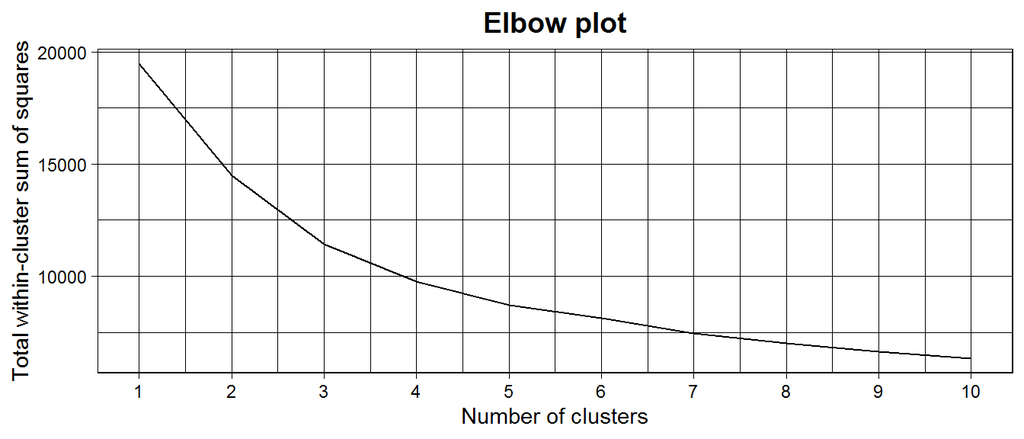

```r
library(purrr)
data.cluster = data.scored %>% dplyr::select(Flight.Distance1, Flight.Count1, ddays1, Online.Services1, On.board.services1, Airport.Services1)

# Use map_dbl to run many models with varying value of k (centers)
tot_withinss <- map_dbl(1:10,  function(k){
  model <- kmeans(x = data.cluster, centers = k)
  model$tot.withinss
})

# Generate a data frame containing both k and tot_withinss
elbow_df <- data.frame(
  k = 1:10,
  tot_withinss = tot_withinss
)

# Plot the elbow plot
 ggplot(elbow_df, aes(x = k, y = tot_withinss)) +
  geom_line() +
  labs(x = "Number of clusters", y ="Total within-cluster sum of squares",title = "Elbow plot") +
  scale_x_continuous(breaks = 1:10) + theme_linedraw() +
  theme(plot.title = element_text(size=14, hjust = 0.5, face="bold"))
```

From the number of 1 to 5 a line goes with wide steps, reducing the total within-cluster sum of squares, however after 5 it slows down and these changes become not so big. So, let’s assign **5 clusters** to the data.

How many observations are here in each cluster after the assignment?

```r
set.seed(111)
clusters <- kmeans(data.scored[,c("Flight.Distance1", "Flight.Count1", "ddays1", "Online.Services1", "On.board.services1", "Airport.Services1")], 5)
data.scored$Cluster <- as.factor(clusters$cluster)

# Look at the distribution of cluster
table(data.scored$Cluster) %>% kable(col.names = c("Cluster", "Amount of customers")) %>% kable_styling(bootstrap_options="striped", full_width = FALSE, position = "left")
```

| Cluster | Amount of customers |
| --- | --- |
| 1 | 13131 |
| 2 | 11252 |
| 3 | 8025 |
| 4 | 16924 |
| 5 | 13020 |

We see that the amount of observations is not homogeneous, yet still large to make some significant interpretations.

Let’s estimate how different these clusters represent the data. Estimation is done on the initial 6 variables, dimensionality is downgraded with PCA.

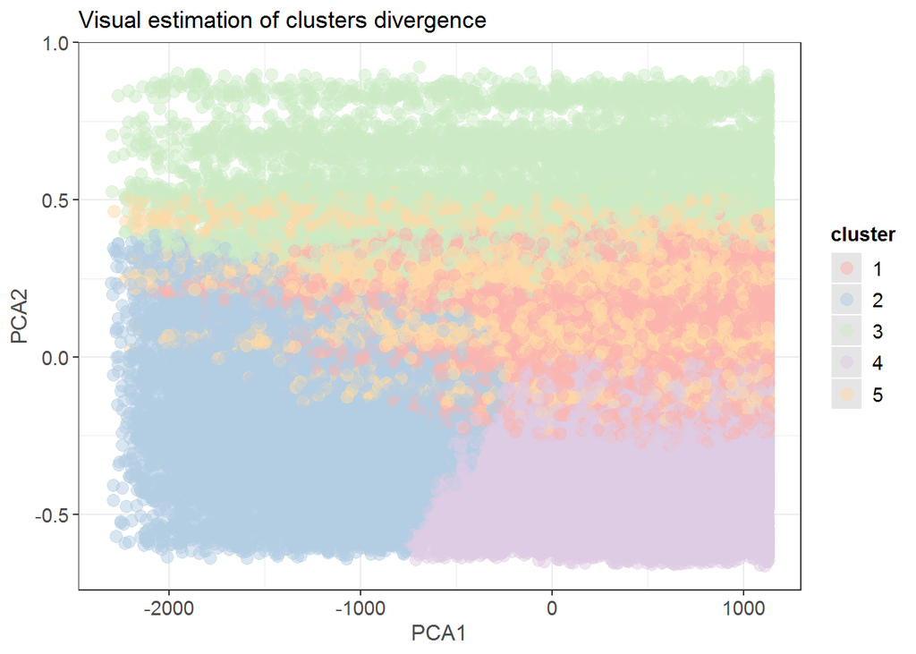

```r
pca <- data.scored %>% dplyr::select(Flight.Distance1, Flight.Count1, ddays, Online.Services1, On.board.services1, Airport.Services1)
pcmp <- princomp(pca)
pred_pc <- predict(pcmp, newdata=pca)[,1:2]
clusters <- data.scored$Cluster
library(data.table)
comp_dt <- cbind(as.data.table(pred_pc), cluster = as.factor(clusters))
ggplot(comp_dt,aes(Comp.1,Comp.2))+ geom_point(aes(color = cluster),size=3, alpha = 0.5) + xlab("PCA1") + ylab("PCA2") + ggtitle("Visual estimation of clusters divergence") + scale_color_brewer(palette = "Pastel1")
```

We see that the clusters have a good divergence in the 2, 3 and 4 groups, however have some similarity and imposition in 1st and 5th groups. However, we’ve tried less and more amount of k-means and divergence in groups remained or even became more messy, so we’ve decided to stay with the number of 5.

Let’s dive into exploration further.

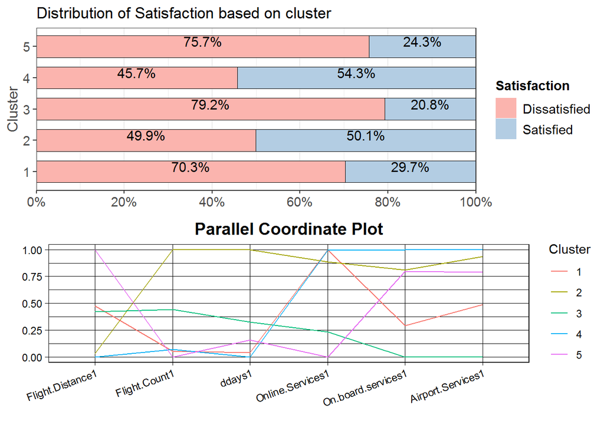

```r
# Grouping by the cluster assignment and calculate averages
data.mean <- data.scored %>% dplyr::select(Flight.Distance1, Flight.Count1, ddays1, Online.Services1, On.board.services1, Airport.Services1, Cluster) %>% group_by(Cluster) %>% summarize_if(is.numeric,mean)

# Creating the min-max scaling function
min_max_standard <- function(x) {
  (x - min(x))/(max(x)-min(x))
}

# Applying
data.minmax <- data.mean %>% mutate_if(is.numeric, min_max_standard)


# Creating a parallel coordinate plot of the values, starts with column 2
library(GGally)

parrallel_plot = ggparcoord(data.minmax, columns = 2:ncol(data.minmax),
           groupColumn = "Cluster", scale = "globalminmax")  +
  labs(x = "", y = "",title = "Parallel Coordinate Plot") + theme_linedraw() +
  theme(plot.title = element_text(size=14, hjust = 0.5, face="bold")) + theme(axis.text.x = element_text(angle = 20, vjust = 1, hjust=1))

clusters_satisfaction_plot = plot_xtab(data.scored$Cluster, data.scored$Satisfaction,
         margin = "row",
         bar.pos = "stack",show.legend = T, show.n = F, coord.flip = T,
          geom.colors = "Pastel1",
         title = "Distribution of Satisfaction based on cluster")

grid.arrange(clusters_satisfaction_plot, parrallel_plot, nrow = 2)
```

**Uplifting hypothesis**: according to this cluster partition, we can uplift all of these segments, but especially 1st, 3rd and 5th clusters - those, who choose to fly on medium and long distances. We have higher chances for it with the 3rd cluster - customers here were for a long time with us, had weighty times of flies with us and may be inclined to come back.

### Model 1: Evaluation

Let’s check what we can do for each cluster as the uplift policy. We’ve used random-forest model from `randomforest` package.

#### Cluster 1

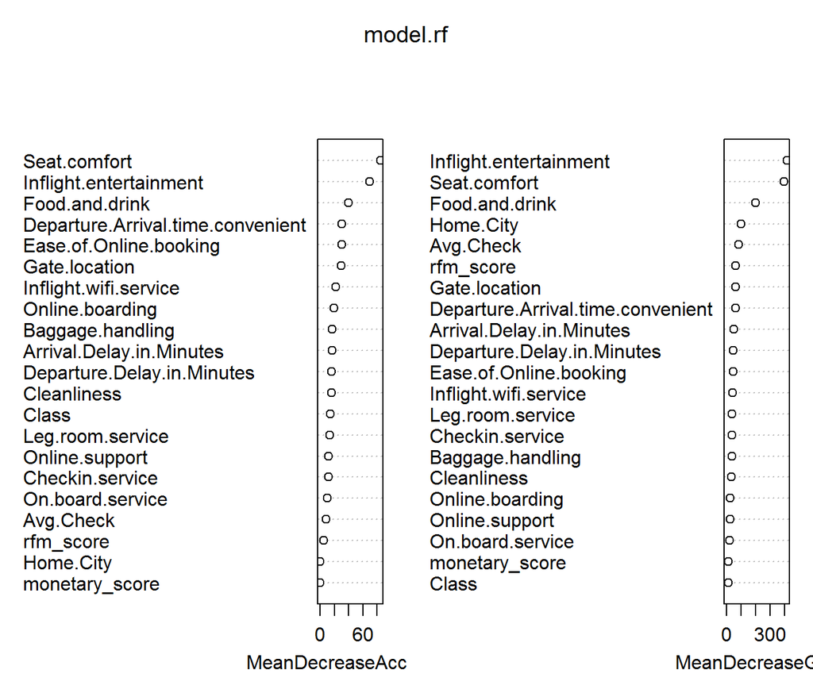

```r
library(dplyr)
# creating new dataset for random forest
model_data <- data.scored %>% dplyr::select(1:25, Cluster) %>% filter(Cluster==1)
model_data$customer_id <- as.character(seq.int(nrow(model_data)))
model_data <- left_join(model_data, rfm_table, by = "customer_id") %>% na.omit() %>% dplyr::select(-c(27:32), -customer_id, Satisfaction, -Loyalty_card, -Cluster)

# correcting the types of variables
model_data$Gender <- as.factor(model_data$Gender)
model_data$Home.City <- as.factor(model_data$Home.City)
model_data$Class <- as.factor(model_data$Class)
model_data$Satisfaction <- as.factor(model_data$Satisfaction)

# splitting to train and test
library(caret)
set.seed(222)
d_test = createDataPartition(model_data$Satisfaction, p = 0.2, list = FALSE)
data_test = model_data[d_test,]
data_train = model_data[-d_test,]

#training a model
library(randomForest)
set.seed(1)
model.rf=randomForest(Satisfaction~.-Flight.Count-Flight.Distance-Gender-Age,data=data_train, mtry=5, importance=TRUE)

# Checking the accuracy
predTest.rf = predict(model.rf, data_test)
varImpPlot(model.rf)
```

```r
confusion <- caret::confusionMatrix(predTest.rf, data_test$Satisfaction, mode = "prec_recall", positive = "Dissatisfied")
accuracy_model <- (confusion$table[1,1] + confusion$table[2,2])/sum(confusion$table)

confusion$table %>%
  kable(caption = 'Real value/Prediction') %>%
  kable_styling("striped", full_width = F, position = "left")
```

Real value/Prediction

|  | Dissatisfied | Satisfied |
| --- | --- | --- |
| Dissatisfied | 838 | 44 |
| Satisfied | 36 | 258 |

```r
precision = confusion$table[1,1]/(confusion$table[1, 1]+confusion$table[1, 2])
recall = confusion$table[1,1]/(confusion$table[1, 1]+confusion$table[2, 1])
F1 = 2*precision*recall/(precision+recall)

Po = accuracy_model
a = ((confusion$table[1,1]+confusion$table[1,2])*(confusion$table[1,1]+confusion$table[2,1]))/sum(confusion$table)
b = ((confusion$table[2,1]+confusion$table[2,2])*(confusion$table[1,2]+confusion$table[2,2]))/sum(confusion$table)
Pe = (a+b)/sum(confusion$table)

Kappa = (Po-Pe)/(1-Pe)

metrics <- data.frame(Metrics = c("Accuracy", "Precision", "Recall", "F1", "Kappa"), Value = c(round(accuracy_model, 4), round(precision, 4), round(recall, 4), round(F1, 4), round(Kappa, 4)))

metrics %>%
  kable(caption = 'Metrics of model quality') %>%
  kable_styling("striped", full_width = T, position = "left")
```

Metrics of model quality

| Metrics | Value |
| --- | --- |
| Accuracy | 0.9320 |
| Precision | 0.9501 |
| Recall | 0.9588 |
| F1 | 0.9544 |
| Kappa | 0.8202 |

```r
m1 <- metrics
colnames(m1) <- c("Metrics", "M1.1.Value")
```

```r
# monetary gain/loss
model_dataa <- data.scored %>% dplyr::select(Satisfaction, Cluster, revenue) %>% filter(Cluster==1, Satisfaction =="Satisfied")
mean_sat <- mean(model_dataa$revenue)

# estimating gain/loss
model_datab <- data.scored %>% dplyr::select(Satisfaction, Cluster, revenue) %>% filter(Cluster==1, Satisfaction =="Dissatisfied")
mean_dis <- mean(model_datab$revenue)

monetary_gain = (838+258)*mean_sat
monetary_loss = (44+36)*mean_dis
decrease_by = monetary_loss/monetary_gain
total = (838+258)*mean_sat - (44+36)*mean_dis

cbind(mean_sat, mean_dis, monetary_gain, monetary_loss, total, decrease_by) %>% kable()%>% kable_styling(bootstrap_options = "striped", full_width = T, position = "left")
```

| mean_sat | mean_dis | monetary_gain | monetary_loss | total | decrease_by |
| --- | --- | --- | --- | --- | --- |
| 618688.1 | 369705.6 | 678082180 | 29576451 | 648505729 | 0.0436178 |

In terms of **monetary gain/loss**, mean revenue of the satisfied users is 618688, dissatsfied - 369706, and in a total accuracy of prediction = .93 total revenue will decrease in 0.04 times.

#### Cluster 2

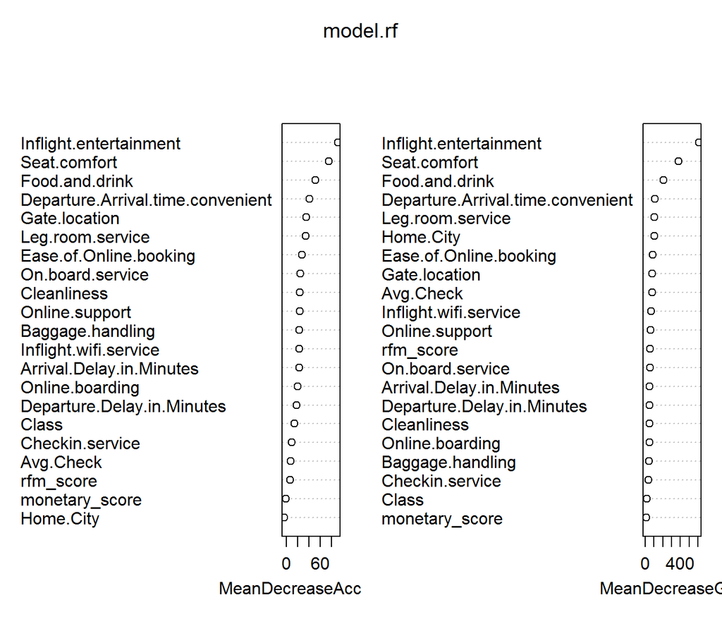

```r
# creating new dataset for random forest
model_data <- data.scored %>% dplyr::select(1:25, Cluster) %>% filter(Cluster==2)
model_data$customer_id <- as.character(seq.int(nrow(model_data)))
model_data <- left_join(model_data, rfm_table, by = "customer_id") %>% na.omit() %>% dplyr::select(-c(27:32), -customer_id, Satisfaction, -Loyalty_card, -Cluster)

# correcting the types of variables
model_data$Gender <- as.factor(model_data$Gender)
model_data$Home.City <- as.factor(model_data$Home.City)
model_data$Class <- as.factor(model_data$Class)
model_data$Satisfaction <- as.factor(model_data$Satisfaction)

# splitting to train and test
library(caret)
set.seed(222)
d_test = createDataPartition(model_data$Satisfaction, p = 0.2, list = FALSE)
data_test = model_data[d_test,]
data_train = model_data[-d_test,]

#training a model
library(randomForest)
set.seed(1)
model.rf=randomForest(Satisfaction~.-Flight.Count-Flight.Distance-Gender-Age,data=data_train, mtry=5, importance=TRUE)

# Checking the accuracy
predTest.rf = predict(model.rf, data_test)
varImpPlot(model.rf)
```

```r
confusion <- caret::confusionMatrix(predTest.rf, data_test$Satisfaction, mode = "prec_recall", positive = "Dissatisfied")
accuracy_model <- (confusion$table[1,1] + confusion$table[2,2])/sum(confusion$table)

confusion$table %>%
  kable(caption = 'Real value/Prediction') %>%
  kable_styling("striped", full_width = F, position = "left")
```

Real value/Prediction

|  | Dissatisfied | Satisfied |
| --- | --- | --- |
| Dissatisfied | 530 | 46 |
| Satisfied | 49 | 522 |

```r
precision = confusion$table[1,1]/(confusion$table[1, 1]+confusion$table[1, 2])
recall = confusion$table[1,1]/(confusion$table[1, 1]+confusion$table[2, 1])
F1 = 2*precision*recall/(precision+recall)

Po = accuracy_model
a = ((confusion$table[1,1]+confusion$table[1,2])*(confusion$table[1,1]+confusion$table[2,1]))/sum(confusion$table)
b = ((confusion$table[2,1]+confusion$table[2,2])*(confusion$table[1,2]+confusion$table[2,2]))/sum(confusion$table)
Pe = (a+b)/sum(confusion$table)

Kappa = (Po-Pe)/(1-Pe)

metrics <- data.frame(Metrics = c("Accuracy", "Precision", "Recall", "F1", "Kappa"), Value = c(round(accuracy_model, 4), round(precision, 4), round(recall, 4), round(F1, 4), round(Kappa, 4)))

metrics %>%
  kable(caption = 'Metrics of model quality') %>%
  kable_styling("striped", full_width = T, position = "left")
```

Metrics of model quality

| Metrics | Value |
| --- | --- |
| Accuracy | 0.9172 |
| Precision | 0.9201 |
| Recall | 0.9154 |
| F1 | 0.9177 |
| Kappa | 0.8343 |

```r
m2 <- metrics
colnames(m2) <- c("Metrics", "M1.2.Value")
```

This model has high accuracy - it predicts 91% of the data, have 91% of sensitivity and 91% specificity. These high metrics say that this model shows good performance. According to the estimation of model’s predictors we can say that customers in this cluster crucially value entertainment during flight, comfortable seats, food and drinks, convenience of arrival time , location of the gate and legroom service.

```r
# monetary gain/loss
model_dataa <- data.scored %>% dplyr::select(Satisfaction, Cluster, revenue) %>% filter(Cluster==2, Satisfaction =="Satisfied")
mean_sat <- mean(model_dataa$revenue)

# estimating gain/loss
model_datab <- data.scored %>% dplyr::select(Satisfaction, Cluster, revenue) %>% filter(Cluster==2, Satisfaction =="Dissatisfied")
mean_dis <- mean(model_datab$revenue)

monetary_gain = (530+522)*mean_sat
monetary_loss = (46+49)*mean_dis
decrease_by = monetary_loss/monetary_gain
total = (530+522)*mean_sat - (46+49)*mean_dis

cbind(mean_sat, mean_dis, monetary_gain, monetary_loss, total, decrease_by) %>% kable()%>% kable_styling(bootstrap_options = "striped", full_width = T, position = "left")
```

| mean_sat | mean_dis | monetary_gain | monetary_loss | total | decrease_by |
| --- | --- | --- | --- | --- | --- |
| 849221 | 610335.3 | 893380505 | 57981851 | 835398655 | 0.0649016 |

#### Cluster 3

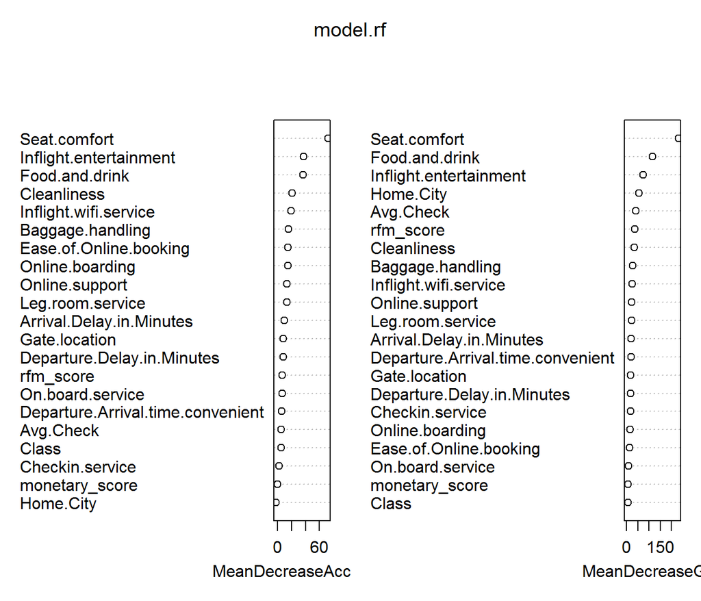

```r
# creating new dataset for random forest
model_data <- data.scored %>% dplyr::select(1:25, Cluster) %>% filter(Cluster==3)
model_data$customer_id <- as.character(seq.int(nrow(model_data)))
model_data <- left_join(model_data, rfm_table, by = "customer_id") %>% na.omit() %>% dplyr::select(-c(27:32), -customer_id, Satisfaction, -Loyalty_card, -Cluster)

# correcting the types of variables
model_data$Gender <- as.factor(model_data$Gender)
model_data$Home.City <- as.factor(model_data$Home.City)
model_data$Class <- as.factor(model_data$Class)
model_data$Satisfaction <- as.factor(model_data$Satisfaction)

# splitting to train and test
library(caret)
set.seed(222)
d_test = createDataPartition(model_data$Satisfaction, p = 0.2, list = FALSE)
data_test = model_data[d_test,]
data_train = model_data[-d_test,]

#training a model
library(randomForest)
set.seed(1)
model.rf=randomForest(Satisfaction~.-Flight.Count-Flight.Distance-Gender-Age,data=data_train, mtry=5, importance=TRUE)

# Checking the accuracy
predTest.rf = predict(model.rf, data_test)
varImpPlot(model.rf)
```

```r
confusion <- caret::confusionMatrix(predTest.rf, data_test$Satisfaction, mode = "prec_recall", positive = "Dissatisfied")
accuracy_model <- (confusion$table[1,1] + confusion$table[2,2])/sum(confusion$table)

confusion$table %>%
  kable(caption = 'Real value/Prediction') %>%
  kable_styling("striped", full_width = F, position = "left")
```

Real value/Prediction

|  | Dissatisfied | Satisfied |
| --- | --- | --- |
| Dissatisfied | 577 | 44 |
| Satisfied | 7 | 84 |

```r
precision = confusion$table[1,1]/(confusion$table[1, 1]+confusion$table[1, 2])
recall = confusion$table[1,1]/(confusion$table[1, 1]+confusion$table[2, 1])
F1 = 2*precision*recall/(precision+recall)

Po = accuracy_model
a = ((confusion$table[1,1]+confusion$table[1,2])*(confusion$table[1,1]+confusion$table[2,1]))/sum(confusion$table)
b = ((confusion$table[2,1]+confusion$table[2,2])*(confusion$table[1,2]+confusion$table[2,2]))/sum(confusion$table)
Pe = (a+b)/sum(confusion$table)

Kappa = (Po-Pe)/(1-Pe)

metrics <- data.frame(Metrics = c("Accuracy", "Precision", "Recall", "F1", "Kappa"), Value = c(round(accuracy_model, 4), round(precision, 4), round(recall, 4), round(F1, 4), round(Kappa, 4)))

metrics %>%
  kable(caption = 'Metrics of model quality') %>%
  kable_styling("striped", full_width = T, position = "left")
```

Metrics of model quality

| Metrics | Value |
| --- | --- |
| Accuracy | 0.9284 |
| Precision | 0.9291 |
| Recall | 0.9880 |
| F1 | 0.9577 |
| Kappa | 0.7262 |

```r
m3 <- metrics
colnames(m3) <- c("Metrics", "M1.3.Value")
```

```r
# monetary gain/loss
model_dataa <- data.scored %>% dplyr::select(Satisfaction, Cluster, revenue) %>% filter(Cluster==3, Satisfaction =="Satisfied")
mean_sat <- mean(model_dataa$revenue)

# estimating gain/loss
model_datab <- data.scored %>% dplyr::select(Satisfaction, Cluster, revenue) %>% filter(Cluster==3, Satisfaction =="Dissatisfied")
mean_dis <- mean(model_datab$revenue)

monetary_gain = (577+84)*mean_sat
monetary_loss = (7+44)*mean_dis
decrease_by = monetary_loss/monetary_gain
total = (577+84)*mean_sat - (7+44)*mean_dis

cbind(mean_sat, mean_dis, monetary_gain, monetary_loss, total, decrease_by) %>% kable()%>% kable_styling(bootstrap_options = "striped", full_width = T, position = "left")
```

| mean_sat | mean_dis | monetary_gain | monetary_loss | total | decrease_by |
| --- | --- | --- | --- | --- | --- |
| 1028865 | 448009.6 | 680079591 | 22848492 | 657231099 | 0.0335968 |

In terms of **monetary gain/loss**, mean revenue of the satisfied users is 1028865, dissatsfied - 448009.6, and in a total accuracy of prediction = .92 total revenue will decrease in 0.03 times.

#### Cluster 4

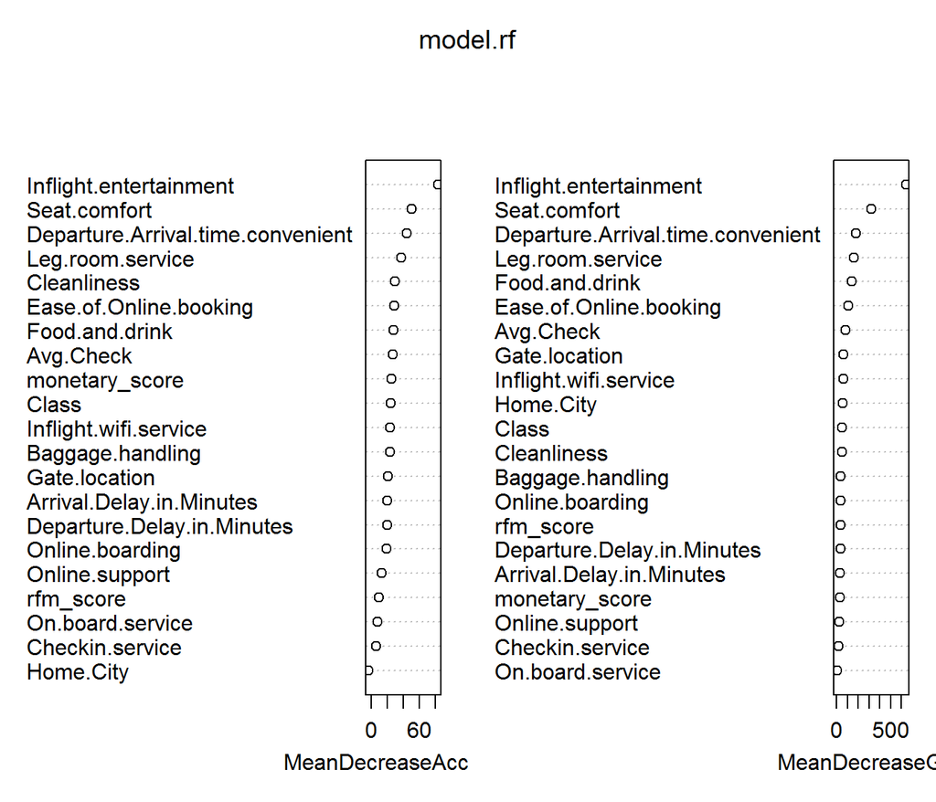

```r
# creating new dataset for random forest
model_data <- data.scored %>% dplyr::select(1:25, Cluster) %>% filter(Cluster==4)
model_data$customer_id <- as.character(seq.int(nrow(model_data)))
model_data <- left_join(model_data, rfm_table, by = "customer_id") %>% na.omit() %>% dplyr::select(-c(27:32), -customer_id, Satisfaction, -Loyalty_card, -Cluster)

# correcting the types of variables
model_data$Gender <- as.factor(model_data$Gender)
model_data$Home.City <- as.factor(model_data$Home.City)
model_data$Class <- as.factor(model_data$Class)
model_data$Satisfaction <- as.factor(model_data$Satisfaction)

# splitting to train and test
library(caret)
set.seed(222)
d_test = createDataPartition(model_data$Satisfaction, p = 0.2, list = FALSE)
data_test = model_data[d_test,]
data_train = model_data[-d_test,]

#training a model
library(randomForest)
set.seed(1)
model.rf=randomForest(Satisfaction~.-Flight.Count-Flight.Distance-Gender-Age,data=data_train, mtry=5, importance=TRUE)

# Checking the accuracy
predTest.rf = predict(model.rf, data_test)
varImpPlot(model.rf)
```

```r
confusion <- caret::confusionMatrix(predTest.rf, data_test$Satisfaction, mode = "prec_recall", positive = "Dissatisfied")
accuracy_model <- (confusion$table[1,1] + confusion$table[2,2])/sum(confusion$table)

confusion$table %>%
  kable(caption = 'Real value/Prediction') %>%
  kable_styling("striped", full_width = F, position = "left")
```

Real value/Prediction

|  | Dissatisfied | Satisfied |
| --- | --- | --- |
| Dissatisfied | 386 | 12 |
| Satisfied | 31 | 784 |

```r
precision = confusion$table[1,1]/(confusion$table[1, 1]+confusion$table[1, 2])
recall = confusion$table[1,1]/(confusion$table[1, 1]+confusion$table[2, 1])
F1 = 2*precision*recall/(precision+recall)

Po = accuracy_model
a = ((confusion$table[1,1]+confusion$table[1,2])*(confusion$table[1,1]+confusion$table[2,1]))/sum(confusion$table)
b = ((confusion$table[2,1]+confusion$table[2,2])*(confusion$table[1,2]+confusion$table[2,2]))/sum(confusion$table)
Pe = (a+b)/sum(confusion$table)

Kappa = (Po-Pe)/(1-Pe)

metrics <- data.frame(Metrics = c("Accuracy", "Precision", "Recall", "F1", "Kappa"), Value = c(round(accuracy_model, 4), round(precision, 4), round(recall, 4), round(F1, 4), round(Kappa, 4)))

metrics %>%
  kable(caption = 'Metrics of model quality') %>%
  kable_styling("striped", full_width = T, position = "float_left")
```

Metrics of model quality

| Metrics | Value |
| --- | --- |
| Accuracy | 0.9646 |
| Precision | 0.9698 |
| Recall | 0.9257 |
| F1 | 0.9472 |
| Kappa | 0.9206 |

```r
m4 <- metrics
colnames(m4) <- c(".Metrics", "M1.4Value")
```

```r
# monetary gain/loss
model_dataa <- data.scored %>% dplyr::select(Satisfaction, Cluster, revenue) %>% filter(Cluster==4, Satisfaction =="Satisfied")
mean_sat <- mean(model_dataa$revenue)

# estimating gain/loss
model_datab <- data.scored %>% dplyr::select(Satisfaction, Cluster, revenue) %>% filter(Cluster==4, Satisfaction =="Dissatisfied")
mean_dis <- mean(model_datab$revenue)

monetary_gain = (386+784)*mean_sat
monetary_loss = (31+12)*mean_dis
decrease_by = monetary_loss/monetary_gain
total = (386+784)*mean_sat - (31+12)*mean_dis

cbind(mean_sat, mean_dis, monetary_gain, monetary_loss, total, decrease_by) %>% kable()%>% kable_styling(bootstrap_options = "striped", full_width = T, position = "left")
```

| mean_sat | mean_dis | monetary_gain | monetary_loss | total | decrease_by |
| --- | --- | --- | --- | --- | --- |
| 510044.8 | 393521.4 | 596752376 | 16921419 | 579830958 | 0.0283558 |

In terms of **monetary gain/loss**, mean revenue of the satisfied users is 510044, dissatsfied - 393521, and in a total accuracy of prediction = .96 total revenue will decrease in 0.028 times.

#### Cluster 5

```r
# creating new dataset for random forest
model_data <- data.scored %>% dplyr::select(1:25, Cluster) %>% filter(Cluster==5)
model_data$customer_id <- as.character(seq.int(nrow(model_data)))
model_data <- left_join(model_data, rfm_table, by = "customer_id") %>% na.omit %>% dplyr::select(-c(27:32), -customer_id, Satisfaction, -Loyalty_card, -Cluster)

# correcting the types of variables
model_data$Gender <- as.factor(model_data$Gender)
model_data$Home.City <- as.factor(model_data$Home.City)
model_data$Class <- as.factor(model_data$Class)
model_data$Satisfaction <- as.factor(model_data$Satisfaction)

# splitting to train and test
library(caret)
set.seed(222)
d_test = createDataPartition(model_data$Satisfaction, p = 0.2, list = FALSE)
data_test = model_data[d_test,]
data_train = model_data[-d_test,]

#training a model
library(randomForest)
set.seed(1)
model.rf=randomForest(Satisfaction~.-Flight.Count-Flight.Distance-Gender-Age,data=data_train, mtry=5, importance=TRUE)

# Checking the accuracy
predTest.rf = predict(model.rf, data_test)
confusionMatrix(predTest.rf, data_test$Satisfaction, positive = "Satisfied")
```

```
## Confusion Matrix and Statistics
##
##               Reference
## Prediction     Dissatisfied Satisfied
##   Dissatisfied          889        54
##   Satisfied              32       200
##
##                Accuracy : 0.9268
##                  95% CI : (0.9104, 0.941)
##     No Information Rate : 0.7838
##     P-Value [Acc > NIR] : < 0.0000000000000002
##
##                   Kappa : 0.777
##
##  Mcnemar's Test P-Value : 0.02354
##
##             Sensitivity : 0.7874
##             Specificity : 0.9653
##          Pos Pred Value : 0.8621
##          Neg Pred Value : 0.9427
##              Prevalence : 0.2162
##          Detection Rate : 0.1702
##    Detection Prevalence : 0.1974
##       Balanced Accuracy : 0.8763
##
##        'Positive' Class : Satisfied
##
```

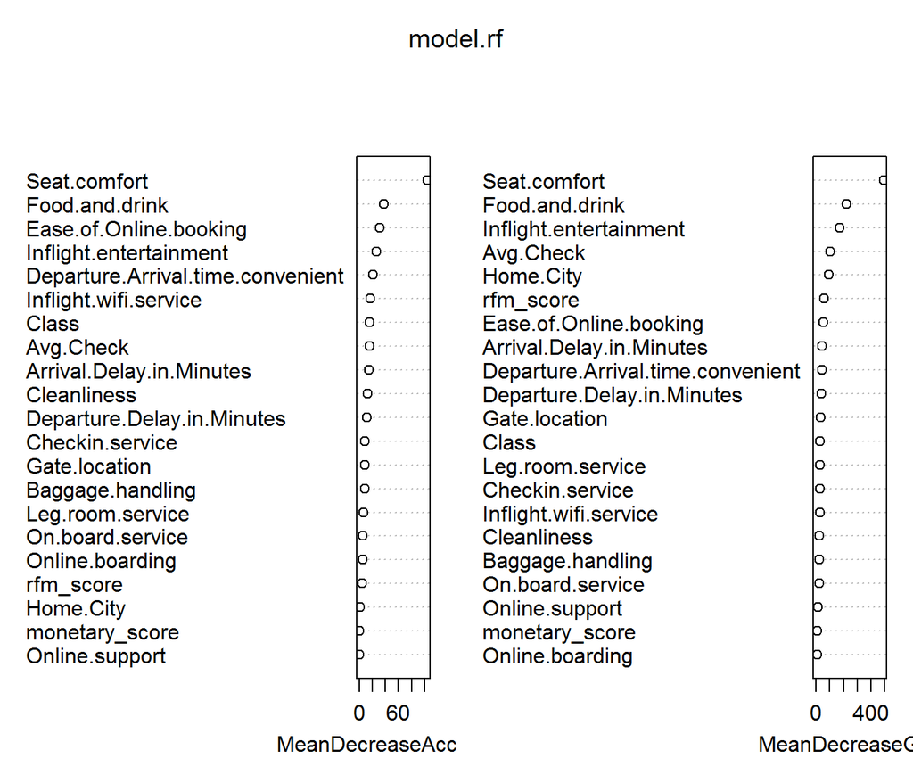

```r
varImpPlot(model.rf)
```

This model has high accuracy - it predicts 92% of the data, has 78% of sensitivity and 96% specificity. These metrics are slightly shyer than in previous models, however still high and cansay that this model can be trusted. According to the estimation of model’s predictors we can say that customers in this cluster crucially value comfortable seats, food and drinks, convinience of online booking, inflight entertainment.

```r
# monetary gain/loss
model_dataa <- data.scored %>% dplyr::select(Satisfaction, Cluster, revenue) %>% filter(Cluster==5, Satisfaction =="Satisfied")
mean_sat <- mean(model_dataa$revenue)

# estimating gain/loss
model_datab <- data.scored %>% dplyr::select(Satisfaction, Cluster, revenue) %>% filter(Cluster==5, Satisfaction =="Dissatisfied")
mean_dis <- mean(model_datab$revenue)

monetary_gain = (889+200)*mean_sat
monetary_loss = (32+54)*mean_dis
decrease_by = monetary_loss/monetary_gain
total = (889+200)*mean_sat - (32+54)*mean_dis

cbind(mean_sat, mean_dis, monetary_gain, monetary_loss, total, decrease_by) %>% kable()%>% kable_styling(bootstrap_options = "striped", full_width = T, position = "left")
```

| mean_sat | mean_dis | monetary_gain | monetary_loss | total | decrease_by |
| --- | --- | --- | --- | --- | --- |
| 506062.4 | 409798.8 | 551101907 | 35242699 | 515859208 | 0.0639495 |

```r
m5 <- metrics
colnames(m5) <- c("Metrics", "M1.5.Value")
```

In terms of **monetary gain/loss**, mean revenue of the satisfied users is 506062.4, dissatsfied - 409798.8, and in a total accuracy of prediction = .93 total revenue will decrease in 0.06 times.

### Model # 2: Logistic Regression

Now we will build a logistic regression model in otrder to predict whether the customer is satisfied by the services of not. For this model we will use the same predictors as for clusterisation so that we could compare the models further. These predictors are Flight.Distance, Flight.Count, D.Days, Online.Services, On.Board.Services and Airport.Services.

```r
model_data <- data %>% select(Flight.Distance, Flight.Count, ddays, online_services, On.board.services, airport_services, Satisfaction)

colnames(model_data) <- c("Flight.Distance", "Flight.Count", "D.Days", "Online.Services", "On.Board.Services", "Airport.Services", "Satisfaction")

model_data$Satisfaction <- as.factor(model_data$Satisfaction)
```

```r
library(caret)
set.seed(222)
d_test = createDataPartition(model_data$Satisfaction, p = 0.2, list = FALSE)
data_test = model_data[d_test,]
data_train = model_data[-d_test,]
```

```r
logistic_model = glm(Satisfaction~., data = data_train, family = "binomial")
#summary(logistic_model)

model_results <- as.data.frame(logistic_model$coefficients)

model_results$p_value <- c("< 0.0000000000000002", "< 0.0000000000000002", "< 0.0000000000000002", 0.0143, 0.00000618, "< 0.0000000000000002", "< 0.0000000000000002")

model_results$coefficients <- model_results$`logistic_model$coefficients`

model_results %>% select(coefficients, p_value) %>% kable(col.names = c("Coefficient", "P-value")) %>% kable_styling(bootstrap_options="striped", full_width = FALSE, position = "left")
```

|  | Coefficient | P-value |
| --- | --- | --- |
| (Intercept) | -5.5320484 | < 0.0000000000000002 |
| Flight.Distance | -0.0004703 | < 0.0000000000000002 |
| Flight.Count | 0.0609747 | < 0.0000000000000002 |
| D.Days | 0.0000327 | 0.0143 |
| Online.Services | 0.0348074 | 0.00000618 |
| On.Board.Services | 1.9132356 | < 0.0000000000000002 |
| Airport.Services | -0.3409882 | < 0.0000000000000002 |

The results of the model show that the effects of all factors on customers’ satisfaction are statistically significant.

### Model 2: Evaluation

For the evaluation of the model’s quality we need to look at confusion matrix and the metrics of accuracy, precision, recall, F1 and Kappa.

```r
test <- predict(logistic_model, data_test, type="response")
pred <- factor(ifelse(test > 0.5,"Satisfied","Dissatisfied"))
```

```r
confusion <- caret::confusionMatrix(pred, data_test$Satisfaction, mode = "prec_recall", positive = "Dissatisfied")
accuracy_model <- (confusion$table[1,1] + confusion$table[2,2])/sum(confusion$table)

confusion$table %>%
  kable(caption = 'Real value/Prediction') %>%
  kable_styling("striped", full_width = F, position = "left")
```

Real value/Prediction

|  | Dissatisfied | Satisfied |
| --- | --- | --- |
| Dissatisfied | 6780 | 1684 |
| Satisfied | 978 | 3030 |

```r
precision = confusion$table[1,1]/(confusion$table[1, 1]+confusion$table[1, 2])
recall = confusion$table[1,1]/(confusion$table[1, 1]+confusion$table[2, 1])
F1 = 2*precision*recall/(precision+recall)

Po = accuracy_model
a = ((confusion$table[1,1]+confusion$table[1,2])*(confusion$table[1,1]+confusion$table[2,1]))/sum(confusion$table)
b = ((confusion$table[2,1]+confusion$table[2,2])*(confusion$table[1,2]+confusion$table[2,2]))/sum(confusion$table)
Pe = (a+b)/sum(confusion$table)

Kappa = (Po-Pe)/(1-Pe)

metrics <- data.frame(Metrics = c("Accuracy", "Precision", "Recall", "F1", "Kappa"), Value = c(round(accuracy_model, 4), round(precision, 4), round(recall, 4), round(F1, 4), round(Kappa, 4)))

metrics %>%
  kable(caption = 'Metrics of model quality') %>%
  kable_styling("striped", full_width = T, position = "float_left")
```

Metrics of model quality

| Metrics | Value |
| --- | --- |
| Accuracy | 0.7866 |
| Precision | 0.8010 |
| Recall | 0.8739 |
| F1 | 0.8359 |
| Kappa | 0.5323 |

```r
m6 <- metrics
colnames(m6) <- c("Metrics", "M2.1.Value")
```

Accuracy of the model is quite good - about 79% of the customers were correctly predicted to be satisfied or not with the services. The value of recall is 0.87 which means that we were able to detect 87% of dissatisfied customers. The precision is slightly lower - among those customers who were classified as dissatisfied only 80% actually belong to this class. The F1 metrics which combines values of precision and recall equals 0.83 which is a good result. Kappa is positive and equals 0.53 which means that our model predicts the satisfaction of customers much better than if we assigned them these classes randomly.

```r
# monetary gain/loss
model_dataa <- data.scored %>% dplyr::select(Satisfaction, revenue) %>% filter(Satisfaction =="Satisfied")
mean_sat <- mean(model_dataa$revenue)

# estimating gain/loss
model_datab <- data.scored %>% dplyr::select(Satisfaction, revenue) %>% filter(Satisfaction =="Dissatisfied")
mean_dis <- mean(model_datab$revenue)

monetary_gain = (6780+3030)*mean_sat
monetary_loss = (1684+978)*mean_dis
decrease_by = monetary_loss/monetary_gain
total = (6780+3030)*mean_sat - (1684+978)*mean_dis

cbind(mean_sat, mean_dis, monetary_gain, monetary_loss, total, decrease_by) %>% kable()%>% kable_styling(bootstrap_options = "striped", full_width = T, position = "left")
```

| mean_sat | mean_dis | monetary_gain | monetary_loss | total | decrease_by |
| --- | --- | --- | --- | --- | --- |
| 645314.4 | 432321.6 | 6330533803 | 1150840067 | 5179693737 | 0.1817919 |

In terms of **monetary gain/loss**, mean revenue of the satisfied users is 645314.4, dissatsfied - 432321.6, and in a total accuracy of prediction = .79 total revenue will decrease in 0.18 times.

### Model 2: Important variables

In order to understand which variables are the most important for the prediction we should look at the table with odds ratio. The value of Odds Ratio shows how big is the effect of the variable: if the value is near 1, there is almost no effect, the value higher than 1 shows povitive effect and the value less than 1 shows negative effect.

```r
coef(logistic_model) %>% exp() %>% round(2) %>% sort(decreasing = T) %>% kable(col.names = "Odds Ratio") %>% kable_styling("striped", full_width = F, position = "left")
```

|  | Odds Ratio |
| --- | --- |
| On.Board.Services | 6.77 |
| Flight.Count | 1.06 |
| Online.Services | 1.04 |
| Flight.Distance | 1.00 |
| D.Days | 1.00 |
| Airport.Services | 0.71 |
| (Intercept) | 0.00 |

From the table we can see that there are only two factors that have some effect on the customers’ satisfaction. Arport services have a small negative effect as the value of odds ratio for it is 0.71 which means that customers, who evaluated the airport services high, have lower chances to be satisfied (chances are multiplied by 0.71) - but this effect can be considered as a mistake of the model. However, On-board services have big positive effect - the odds ratio has value of 6.77 which means that customers, who gave high grade to this type of services have 6.77 times more chances to be generally satisfied. So, on board Services are the most important predictors of customers’ satisfaction.

### Model #2.1: Detailed review of On-board services factor

However, from this model we cannot give any interesting insights about what exact elements of On-board services matter to our customers and, consequently, it is difficult to give reasonable buisness solutions about what should be imprived in on-board services.

In order to solve this problem and get a deeper understanding of what our customers care about the most, we have built another model with the variables which we previously have combined into one On.Board.Services variable. These variables are: Cleanliness, On.board.service, Inflight.entertainment, Inflight.wifi.service, Food.and.drink, Seat.comfort and Leg.room.service.

```r
model_data2 <- data %>% select(Cleanliness, On.board.service, Inflight.entertainment, Inflight.wifi.service, Food.and.drink, Seat.comfort, Leg.room.service, Satisfaction)

model_data2$Satisfaction <- as.factor(model_data2$Satisfaction)
```

```r
set.seed(222)
d_test2 = createDataPartition(model_data2$Satisfaction, p = 0.2, list = FALSE)
data_test2 = model_data2[d_test2,]
data_train2 = model_data2[-d_test2,]
```

We see that the effect of all these factors on customers’ satisfaction is statistically significant.

```r
logistic_model2 = glm(Satisfaction~., data = data_train2, family = "binomial")
#summary(logistic_model2)

model_results2 <- as.data.frame(logistic_model2$coefficients)

model_results2$p_value <- c("< 0.0000000000000002", "0.00000000000000833", "< 0.0000000000000002", "< 0.0000000000000002", "< 0.0000000000000002", "< 0.0000000000000002", "< 0.0000000000000002", "< 0.0000000000000002")

model_results2$coefficients <- model_results2$`logistic_model2$coefficients`

model_results2 %>% select(coefficients, p_value) %>% kable(col.names = c("Coefficient", "P-value")) %>% kable_styling(bootstrap_options="striped", full_width = T, position = "left")
```

|  | Coefficient | P-value |
| --- | --- | --- |
| (Intercept) | -5.1715976 | < 0.0000000000000002 |
| Cleanliness | 0.0673880 | 0.00000000000000833 |
| On.board.service | 0.2122976 | < 0.0000000000000002 |
| Inflight.entertainment | 0.8723184 | < 0.0000000000000002 |
| Inflight.wifi.service | 0.1412959 | < 0.0000000000000002 |
| Food.and.drink | -0.5812459 | < 0.0000000000000002 |
| Seat.comfort | 0.5048730 | < 0.0000000000000002 |
| Leg.room.service | 0.2093743 | < 0.0000000000000002 |

```r
test2 <- predict(logistic_model2, data_test2, type="response")
pred2 <- factor(ifelse(test2 > 0.5,"Satisfied","Dissatisfied"))
confusion2 <- caret::confusionMatrix(pred2, data_test2$Satisfaction, mode = "prec_recall", positive = "Dissatisfied")
```

The accuracy of this model is quite high - almost 80% of the customers were classified correctly. We were able to detect 87% of dissatisfied customers with our model (recall) and 81% of those who we marked as dissatisfied really belong to this class (precision). The value of F1 equals 0.84 which shows a good balance between precision and recall, and Kappa is also quite good - 0.56.

```r
accuracy_model2 <- (confusion2$table[1,1] + confusion2$table[2,2])/sum(confusion2$table)

confusion2$table %>%
  kable(caption = 'Real value/Prediction') %>%
  kable_styling("striped", full_width = F, position = "left")
```

Real value/Prediction

|  | Dissatisfied | Satisfied |
| --- | --- | --- |
| Dissatisfied | 6818 | 1571 |
| Satisfied | 940 | 3143 |

```r
precision2 = confusion2$table[1,1]/(confusion2$table[1, 1]+confusion2$table[1, 2])
recall2 = confusion2$table[1,1]/(confusion2$table[1, 1]+confusion2$table[2, 1])
F1_2 = 2*precision2*recall2/(precision2+recall2)

Po2 = accuracy_model2
a2 = ((confusion2$table[1,1]+confusion2$table[1,2])*(confusion2$table[1,1]+confusion2$table[2,1]))/sum(confusion2$table)
b2 = ((confusion2$table[2,1]+confusion2$table[2,2])*(confusion2$table[1,2]+confusion2$table[2,2]))/sum(confusion2$table)
Pe2 = (a2+b2)/sum(confusion2$table)

Kappa2 = (Po2-Pe2)/(1-Pe2)

metrics2 <- data.frame(Metrics = c("Accuracy", "Precision", "Recall", "F1", "Kappa"), Value = c(round(accuracy_model2, 4), round(precision2, 4), round(recall2, 4), round(F1_2, 4), round(Kappa2, 4)))

metrics2 %>%
  kable(caption = 'Metrics of model quality') %>%
  kable_styling("striped", full_width = T, position = "left")
```

Metrics of model quality

| Metrics | Value |
| --- | --- |
| Accuracy | 0.7987 |
| Precision | 0.8127 |
| Recall | 0.8788 |
| F1 | 0.8445 |
| Kappa | 0.5603 |

```r
m7 <- metrics
colnames(m7) <- c("Metrics", "M2.2.Value")
```

```r
# monetary gain/loss
model_dataa <- data.scored %>% dplyr::select(Satisfaction, revenue) %>% filter(Satisfaction =="Satisfied")
mean_sat <- mean(model_dataa$revenue)

# estimating gain/loss
model_datab <- data.scored %>% dplyr::select(Satisfaction, revenue) %>% filter(Satisfaction =="Dissatisfied")
mean_dis <- mean(model_datab$revenue)

monetary_gain = (6818+3143)*mean_sat
monetary_loss = (940+1571)*mean_dis
decrease_by = monetary_loss/monetary_gain
total = (6818+3143)*mean_sat - (940+1571)*mean_dis

cbind(mean_sat, mean_dis, monetary_gain, monetary_loss, total, decrease_by) %>% kable()%>% kable_styling(bootstrap_options = "striped", full_width = T, position = "left")
```

| mean_sat | mean_dis | monetary_gain | monetary_loss | total | decrease_by |
| --- | --- | --- | --- | --- | --- |
| 645314.4 | 432321.6 | 6427976271 | 1085559507 | 5342416764 | 0.1688804 |

In terms of **monetary gain/loss**, mean revenue of the satisfied users is 645314.4, dissatsfied - 432321.6, and in a total accuracy of prediction = .79 total revenue will decrease in 0.16 times.

Now we shold look at the Odds Ratio of the On-board services to understand which factors have the highest influence on satisfaction of the customers. The most important factor here is Inflight entertainment - customers, who liked the entertainment have 2.39 more chances to be satisfied with the flight - so, it is the first thing we should pay attention to. The next influencing factor is seat comfort - good seats increase the chances of customer satisfaction by 1.66, so the company should work on this point in order to increase customers’ satisfaction. On board service, leg room service and wifi have lower effect on the satisfaction - the chances increase by 1.24, 1.23 and 1.15 respectively - but still should be considered by the company.

```r
coef(logistic_model2) %>% exp() %>% round(2) %>% sort(decreasing = T) %>% kable(col.names = "Odds Ratio") %>% kable_styling("striped", full_width = F, position = "left")
```

|  | Odds Ratio |
| --- | --- |
| Inflight.entertainment | 2.39 |
| Seat.comfort | 1.66 |
| On.board.service | 1.24 |
| Leg.room.service | 1.23 |
| Inflight.wifi.service | 1.15 |
| Cleanliness | 1.07 |
| Food.and.drink | 0.56 |
| (Intercept) | 0.01 |

### Comparing the models

**Disagreement:**

The main disagreement between our models lays in the estimation of variables according to 5 different clusters in the first case and on the whole data in the second. Meaningfulness of variables vary from cluster to cluster and changes it’s places, being, actually, 5 models, and the impact of them is different from the second model.

**Evaluation:**

Models in the second case gave lower estimation metrics than from the first one (e.g. accuracy of 0.79 against 5 accuracies of 0.91-0.96), and monetary loss is also smaller in first models, which makes us incline to choose the first uplift policy.

### What-If analysis on Bayesian belief networks

We decided to find additional data on what actually influences Satisfaction rate in airline industry. We have revised some articles and found out the following: - “Findings indicated that the quality of pre‐flight, in‐flight and post‐flight services had a statistically significant effect on passenger satisfaction.” - “Customer satisfaction is directly related to the service quality provided by any airline company.” - “Quality service expectations in air travel are extremely important in consumer’s behaviour (Parasuraman et al., 1985) as they affect their satisfaction and also lead to buying decisions (Park et al, 2004).”

Bibliography: Namukasa, Juliet. 2013. “The Influence of Airline Service Quality on Passenger Satisfaction and Loyalty: The Case of Uganda Airline Industry.” The TQM Journal 25. doi: 10.1108/TQM-11-2012-0092. Papageorgiou, N. 2016. “Service Quality and Customer Satisfaction in Air Transportation.” Retrieved December 14, 2020 (https://jotr.eu/index.php/volume15/189-service-quality-and-customer-satisfaction-in-air-transportation).

So, we are going to be taking such variables as Flight.Count, online_services,airport_services, On.board.services for our Bayesian network analisys. The assumption is very general and as per following: Higher values for all types of onboard, online and airport services will increase customer satisfaction level.

How can the cusomers react to out improvement policies? We expect from customers with higher satisfaction level tha the customers would bring more revenue to the market. The uplift policies regrading these very variables were described in the section above.

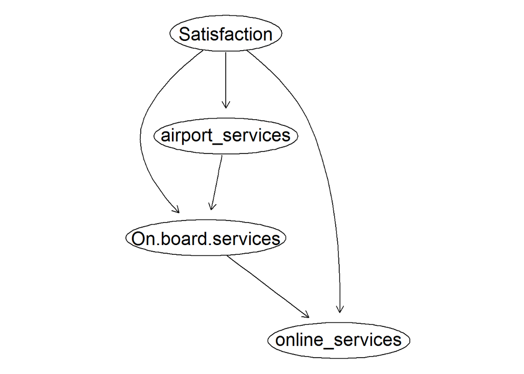

```r
data_bbn = data
data_bbn$online_services = as.numeric(cut2(data$online_services, g = 5))
data_bbn$airport_services = as.numeric(cut2(data$airport_services, g = 5))
data_bbn$On.board.services = as.numeric(cut2(data$On.board.services, g = 5))


names = c(2:33)
data_bbn[,names] = lapply(data_bbn[,names] , factor)
data_bbn$Gender = as.factor(data_bbn$Gender)

data_bbn = data_bbn %>% dplyr::select(Satisfaction, On.board.services, online_services, airport_services)
library(bnlearn)
data_bbn = as.data.frame(data_bbn)
bnStructure = hc(data_bbn)
library(Rgraphviz)
graphviz.plot(bnStructure, shape = "ellipse")
```

We though that this situation is a bit complex and decided to rely on our assumptions about important and significant variable for customer satisfaction rate. Thus, we have decided to reverse the arrows and look closer at the schema. Let;s look at what influences the satisfaction, our general unit of exploration.

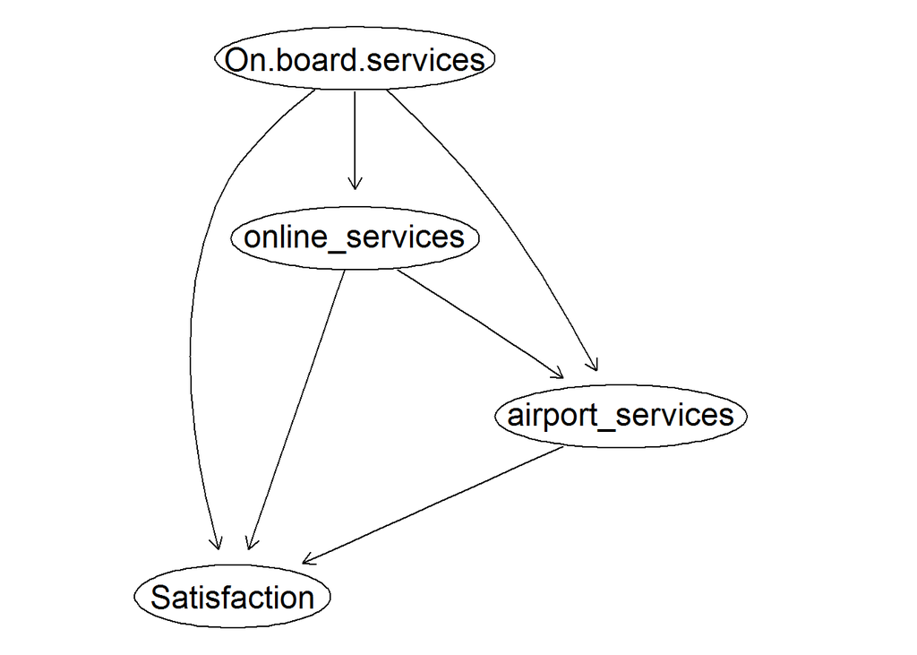

```r
whitelist = data.frame(from = c("online_services", "On.board.services", "airport_services"), to = c('Satisfaction', 'Satisfaction', 'Satisfaction'))

bnStructure = hc(data_bbn, whitelist = whitelist)
graphviz.plot(bnStructure, shape = "ellipse")
```

Let’s calculate probabilities on the data and now let us look at Conditional Probability Tables for the intersection of ALL variables

Firstly we will explore intersections between online and airport services

```r
data_bbn1 = data_bbn %>% dplyr::select(Satisfaction, online_services, airport_services)
whitelist1 = data.frame(from = c("online_services", "airport_services"), to = c('Satisfaction', 'Satisfaction'))
bnStructure1 = hc(data_bbn1, whitelist = whitelist1)
netw1 = bn.fit(bnStructure1, data = data_bbn1)
netw1$Satisfaction
```

```
##
##   Parameters of node Satisfaction (multinomial distribution)
##
## Conditional probability table:
##
## , , airport_services = 1
##
##               online_services
## Satisfaction           1         2         3         4         5
##   Dissatisfied 0.8097698 0.7041607 0.5646158 0.3487544 0.6541445
##   Satisfied    0.1902302 0.2958393 0.4353842 0.6512456 0.3458555
##
## , , airport_services = 2
##
##               online_services
## Satisfaction           1         2         3         4         5
##   Dissatisfied 0.8121936 0.7445573 0.5425868 0.2561350 0.6047875
##   Satisfied    0.1878064 0.2554427 0.4574132 0.7438650 0.3952125
##
## , , airport_services = 3
##
##               online_services
## Satisfaction           1         2         3         4         5
##   Dissatisfied 0.7862870 0.7228874 0.5451431 0.3055556 0.5802128
##   Satisfied    0.2137130 0.2771126 0.4548569 0.6944444 0.4197872
##
## , , airport_services = 4
##
##               online_services
## Satisfaction           1         2         3         4         5
##   Dissatisfied 0.7469682 0.6997743 0.5143824 0.2839080 0.5337591
##   Satisfied    0.2530318 0.3002257 0.4856176 0.7160920 0.4662409
##
## , , airport_services = 5
##
##               online_services
## Satisfaction           1         2         3         4         5
##   Dissatisfied 0.7583756 0.6850095 0.4304348 0.2025692 0.3977927
##   Satisfied    0.2416244 0.3149905 0.5695652 0.7974308 0.6022073
```

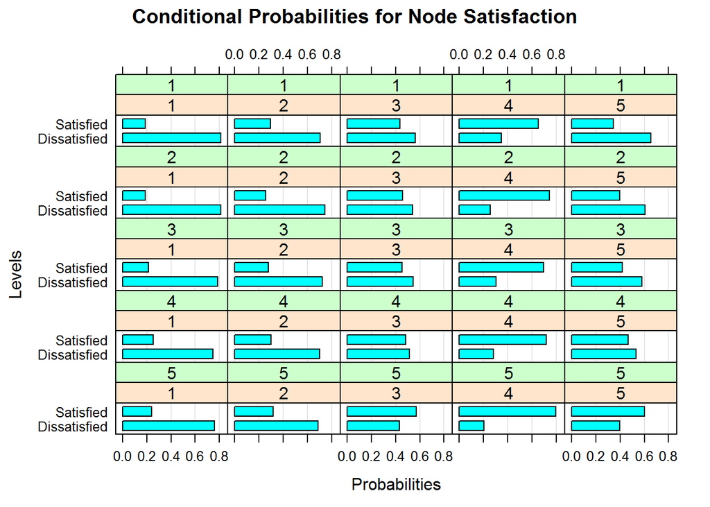

```r
bn.fit.barchart(netw1$Satisfaction)
```

The table shows scores for airport services in green lines and scores for online services in peach lines. We can see that the probability clients are satisfied is higher when airport satisfaction level is equal to 5 and satisfaction of online services is equal to 3. The same results will be when score for online services is equal to 4 independently from the score for airport services. Also, there are more satisfied clients when scores for both services are equal to 5.

Let’s take a look at the intersections of onboard services and online services.

```r
data_bbn2 = data_bbn %>% dplyr::select(Satisfaction, online_services, On.board.services)
whitelist2 = data.frame(from = c("online_services", "On.board.services"), to = c('Satisfaction', 'Satisfaction'))
bnStructure2 = hc(data_bbn2, whitelist = whitelist2)
netw2 = bn.fit(bnStructure2, data = data_bbn2)
netw2$Satisfaction
```

```
##
##   Parameters of node Satisfaction (multinomial distribution)
##
## Conditional probability table:
##
## , , On.board.services = 1
##
##               online_services
## Satisfaction            1          2          3          4          5
##   Dissatisfied 0.86825638 0.79006505 0.69638382 0.70762712 0.78540400
##   Satisfied    0.13174362 0.20993495 0.30361618 0.29237288 0.21459600
##
## , , On.board.services = 2
##
##               online_services
## Satisfaction            1          2          3          4          5
##   Dissatisfied 0.91940086 0.87009346 0.72826981 0.61176471 0.88124306
##   Satisfied    0.08059914 0.12990654 0.27173019 0.38823529 0.11875694
##
## , , On.board.services = 3
##
##               online_services
## Satisfaction            1          2          3          4          5
##   Dissatisfied 0.80298073 0.79580530 0.62529904 0.39323843 0.76418532
##   Satisfied    0.19701927 0.20419470 0.37470096 0.60676157 0.23581468
##
## , , On.board.services = 4
##
##               online_services
## Satisfaction            1          2          3          4          5
##   Dissatisfied 0.54640000 0.58118609 0.44059406 0.23846154 0.55632343
##   Satisfied    0.45360000 0.41881391 0.55940594 0.76153846 0.44367657
##
## , , On.board.services = 5
##
##               online_services
## Satisfaction            1          2          3          4          5
##   Dissatisfied 0.17721519 0.25429799 0.20735334 0.10168434 0.20926292
##   Satisfied    0.82278481 0.74570201 0.79264666 0.89831566 0.79073708
```

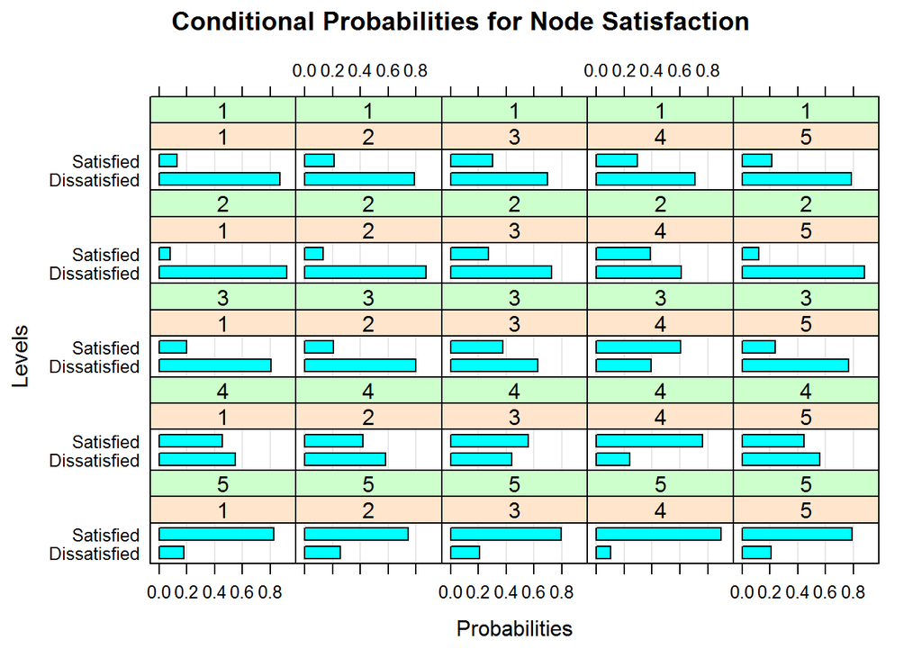

```r
bn.fit.barchart(netw2$Satisfaction)
```

The green color is for onboard services and the peach is for online services. In general, probabilities that customers will be satisfied are higher when onboard services have score 5 independently from online services score.

Let’s take a look at the intersections of onboard services and airpor services.

```r
data_bbn3 = data_bbn %>% dplyr::select(Satisfaction, airport_services, On.board.services)
whitelist3 = data.frame(from = c("airport_services", "On.board.services"), to = c('Satisfaction', 'Satisfaction'))
bnStructure3 = hc(data_bbn3, whitelist = whitelist3)
netw3 = bn.fit(bnStructure3, data = data_bbn3)
netw3$Satisfaction
```

```
##
##   Parameters of node Satisfaction (multinomial distribution)
##
## Conditional probability table:
##
## , , On.board.services = 1
##
##               airport_services
## Satisfaction            1          2          3          4          5
##   Dissatisfied 0.80199667 0.83328309 0.82618862 0.75363322 0.69241192
##   Satisfied    0.19800333 0.16671691 0.17381138 0.24636678 0.30758808
##
## , , On.board.services = 2
##
##               airport_services
## Satisfaction            1          2          3          4          5
##   Dissatisfied 0.76646248 0.82439503 0.87574160 0.90142227 0.92264303
##   Satisfied    0.23353752 0.17560497 0.12425840 0.09857773 0.07735697
##
## , , On.board.services = 3
##
##               airport_services
## Satisfaction            1          2          3          4          5
##   Dissatisfied 0.62943396 0.64300286 0.74088003 0.81455976 0.86128049
##   Satisfied    0.37056604 0.35699714 0.25911997 0.18544024 0.13871951
##
## , , On.board.services = 4
##
##               airport_services
## Satisfaction            1          2          3          4          5
##   Dissatisfied 0.40506958 0.40407103 0.46661055 0.54545455 0.62822796
##   Satisfied    0.59493042 0.59592897 0.53338945 0.45454545 0.37177204
##
## , , On.board.services = 5
##
##               airport_services
## Satisfaction            1          2          3          4          5
##   Dissatisfied 0.19827586 0.19234360 0.23293173 0.22240527 0.15555556
##   Satisfied    0.80172414 0.80765640 0.76706827 0.77759473 0.84444444
```

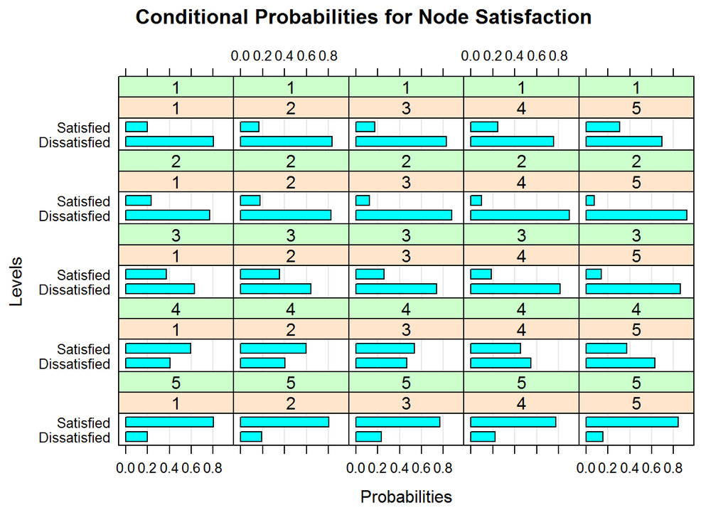

```r
bn.fit.barchart(netw3$Satisfaction)
```

Our general conclusion is that by heightening the quality of onboard services, the clients, woth higher probability, will be satisfied with the condiions, regradless of conditions of online and airport services. still, we have to pay attention to other services in order to obtain the best result for satisfaction level.

### Inference

Now we can use model for inference. Our initial all-sample probability of Satisfaction goes as following:

```r
netw = bn.fit(bnStructure, data = data_bbn)
cpquery(netw, event = (Satisfaction == "Satisfied"), evidence = TRUE)
```

```
## [1] 0.3743
```

That is the probability that our client is satisfied.

Let’s explore different segments.

```r
library(RBGL)
library(gRain)
BBNnet = as.grain(netw)
querygrain(BBNnet, nodes=c("Satisfaction"), type="marginal")
```

```
## $Satisfaction
## Satisfaction
## Dissatisfied    Satisfied
##     0.622049     0.377951
```

Let us look at initial conditional tables and realize which segments have higher levels of probability

```r
querygrain(BBNnet, nodes=c("Satisfaction", "online_services"), type="conditional")
```

```
##               online_services
## Satisfaction           1         2        3         4         5
##   Dissatisfied 0.7868812 0.7138889 0.525297 0.2727728 0.5580511
##   Satisfied    0.2131188 0.2861111 0.474703 0.7272272 0.4419489
```

```r
querygrain(BBNnet, nodes=c("Satisfaction", "airport_services"), type="conditional")
```

```
##               airport_services
## Satisfaction           1         2         3         4        5
##   Dissatisfied 0.6746166 0.6554154 0.6350967 0.5954186 0.510152
##   Satisfied    0.3253834 0.3445846 0.3649033 0.4045814 0.489848
```

```r
querygrain(BBNnet, nodes=c("Satisfaction", "On.board.services"), type="conditional")
```

```
##               On.board.services
## Satisfaction           1         2         3         4         5
##   Dissatisfied 0.8031169 0.8400301 0.7203962 0.4931242 0.1963913
##   Satisfied    0.1968831 0.1599699 0.2796038 0.5068758 0.8036087
```

We can see that the probability of higher satisfcation for those who have score 5, except for one minor exlusion: for online services the score of 4 would have more satisfied clients han for score of 5.

# Executive report

## Existing situation

Let’s have a raw look on the distribution of satisfaction among our customers:

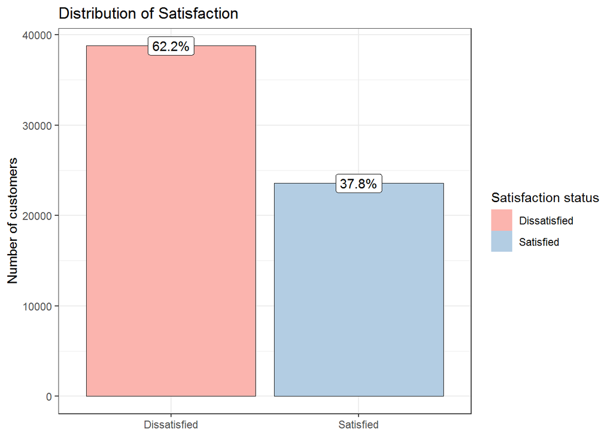

```r
library(stringr)
ggplot(data, aes(x = Satisfaction)) + geom_bar(aes(fill = Satisfaction)) + scale_fill_manual(name = "Satisfaction status", values = c( "Dissatisfied" = "#FBB4AE", "Satisfied" = "#B3CDE3"), labels = c("Dissatisfied","Satisfied")) + geom_label(aes(label= str_c(round(stat(prop)*100, digits = 2), "%"), group=1),stat='count') + ggtitle("Distribution of Satisfaction") + theme_bw() + labs(x = NULL, y = "Number of customers")
```

2/3 are dissatisfied, this is the problem we are going to solve.

**Business Metrics:**

Let’s count sticky factor and all metrics that go along with it. DAU, MAU, WAU will be counted for the year of 2013, because we rely on the latest available data of variable *last_flight* and our date of analysis is 2013-10-01.

```r
data_dau_13 = data %>% filter(year(last_flight) == "2013") %>% group_by(last_flight) %>% dplyr::summarise(n = n())
dau = as.data.frame(mean(data_dau_13$n))
colnames(dau) <- "DAU"
data_wau_13 = data %>% filter(year(last_flight) == "2013") %>% group_by(week(last_flight)) %>% dplyr::summarise(n = n())
wau = as.data.frame(mean(data_wau_13$n))
colnames(wau) <- "WAU"
data_mau_13 = data %>% filter(year(last_flight) == "2013") %>% group_by(month(last_flight)) %>% dplyr::summarise(n = n())
mau = as.data.frame(mean(data_mau_13$n))
colnames(mau) <- "MAU"
a <- as.data.frame(cbind(stick_week = dau/wau * 100, stick_month = dau/mau * 100))
colnames(a) <- c("Weekly Sticky", "Monthly Sticky")
data_satisf = data %>% group_by(Satisfaction) %>% dplyr::summarise(n = n())
csat = data_satisf[2,2] / sum(data_satisf[,2])
csat_score = csat * 100
colnames(csat_score) <- "CSAT"
cbind(dau, wau, mau, a, csat_score) %>% kable() %>% kable_styling(bootstrap_options = "striped", full_width = F, position = "left")
```

| DAU | WAU | MAU | Weekly Sticky | Monthly Sticky | CSAT |
| --- | --- | --- | --- | --- | --- |
| 73.18356 | 504 | 2226 | 14.52055 | 3.287671 | 37.7951 |

We can see that:

- DAU: on average 73 customers fly per day.
- WAU: average 504 customers fly per week
- MAU: on average 2226 customers fly per month.
- The monthly Sticky is roughly 3.3% which means that on average 3% had a flight each day every month.
- The Weekly Sticky is approximately 14.5% which which means that one average 14,5% had a flight each day every week.
- the Customer Satisfaction Score is roughly 37,8%, which is not great.

**RFM**:

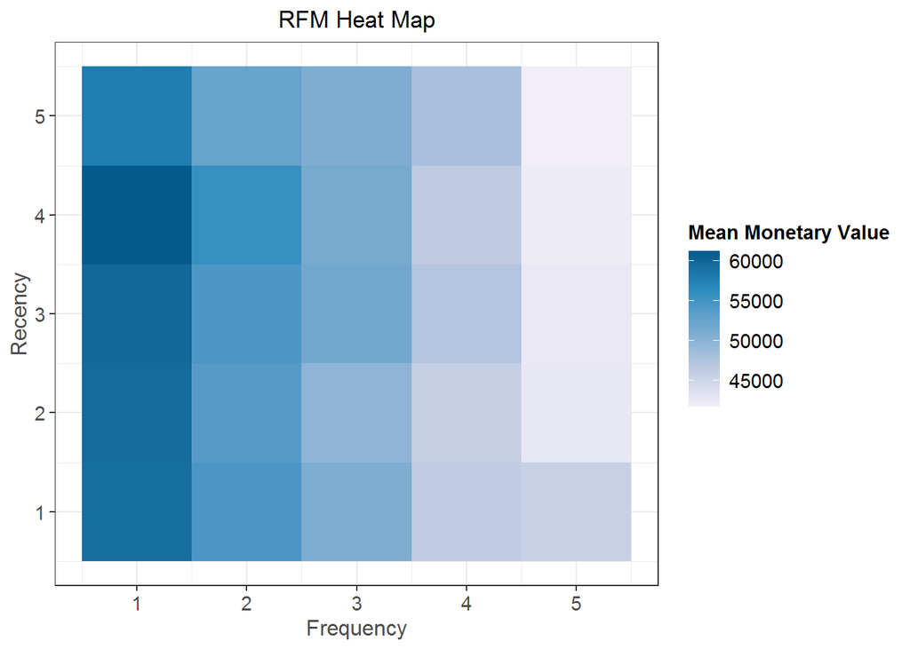

```r
rfm_heatmap(rfm_results)
```

The plot illustrates that even clients with low scores for frequency tend to spend more money on average. The most profitable for the company type of client is the group with 4 for recency and 1 for frequency scores.

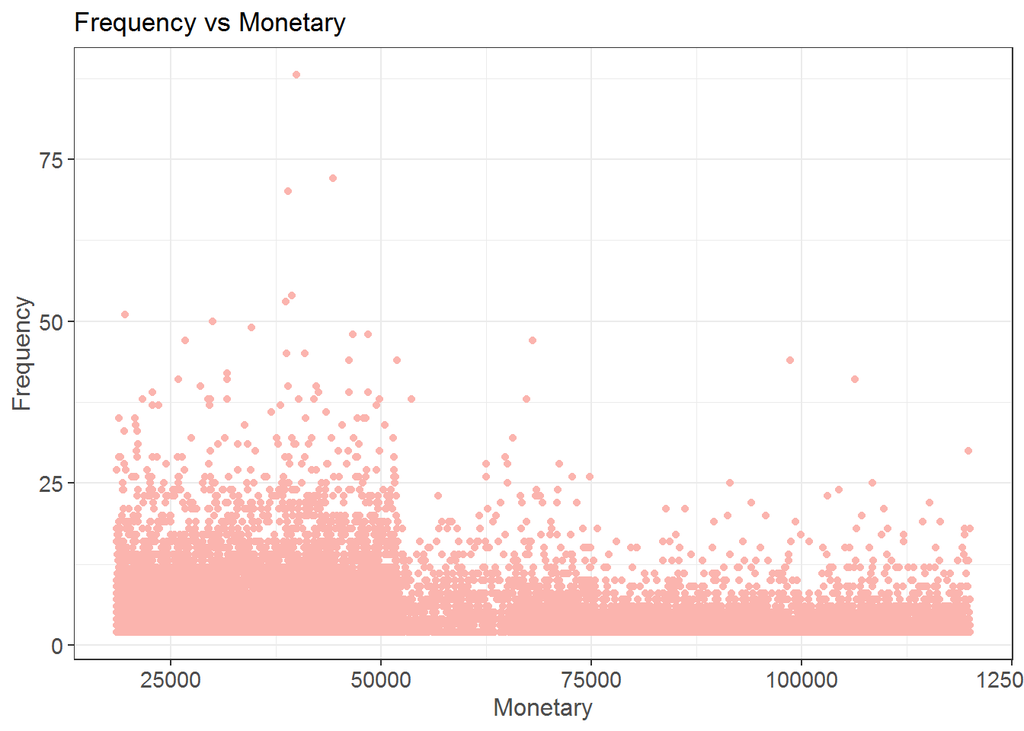

```r
rfm_fm_plot(rfm_results, point_color = "#FBB4AE")
```

Here we can see that clients tend to spend more money on average when they flight not so frequently.

## Metrics by Segmentation:

**Satisfaction by Cluster:**

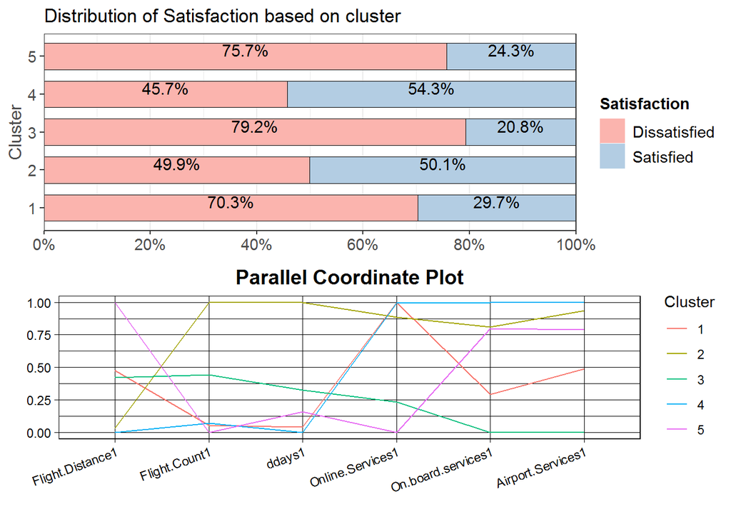

```r
grid.arrange(clusters_satisfaction_plot, parrallel_plot, nrow = 2)
```

We see that most dissatisfied clusters are 1, 3 and 5, however 2 and 4 are also do not have the best division.

## Poicies for uplift:

**Based on Model 1**:

```r
cbind(m1, m2[,2], m3[,2], m4[,2], m5[,2]) %>% kable() %>% kable_styling(bootstrap_options = "striped", full_width = F, position = "left")
```

[output not shown]

Satisfaction-predictive model has worked well together with clusterization. All the models has performed with accuracy more than 90% - predicting 90% of values true, showing monetary loss no more than 6%.

**Based on Model 2:**

```r
cbind(m6, m7[,2]) %>% kable() %>% kable_styling(bootstrap_options = "striped", full_width = F, position = "left")
```

[output not shown]

**Policy 2**:

The most important factor here is Inflight entertainment, so it is the first thing we should pay attention to. The next influencing factor is seat comfort, so the company should work on this point in order to increase customers’ satisfaction. On board service, leg room service and wifi have lower effect on th satisfaction but still should be considered by the company.